# A972 - data prep

Judson Fisher

08/02/2021

```r
# Functions to add to their own file

# Tell summary functions to group by species or not
group_vars <- function(by_species = FALSE) {
  if(by_species) {
    alist(spp, treatment, year)
  } else {
    alist(treatment, year)
  }
}

# color table by groups function, only works if table is
# properly arranged.
color_groups <- function(x, caption = "", background = "#EEE9E9") {
  even_groups <- x %>%
    rownames_to_column() %>%
    filter(cur_group_id() %% 2 == 0) %>%
    pull(rowname) %>%
    as.numeric()
  x %>%
    kbl(caption = caption) %>%
    kable_styling(full_width = FALSE) %>%
    row_spec(even_groups, background = background)
}

# Outlier Function
out <- function(x, mag = 1.5) {
  qu <- quantile(x, c(.25, .75), na.rm = TRUE)
  bounds <- c(lower = qu[[1]] - mag * IQR(x, na.rm = TRUE),
              upper = qu[[2]] + mag * IQR(x, na.rm = TRUE))
  outliers <- x < bounds["lower"] | x > bounds["upper"]
  outliers[is.na(outliers)] <- FALSE
  outliers
}

# Plot ht vs dbh with square root transformation and
# highlight outliers
plot_ht <- function(data, mag = 1.5) {
  mod <- lm(ht ~ sqrt(dbh), data = data)
  plot(data$dbh, data$ht, col = "gray30")
  curve(coef(mod)[1] + coef(mod)[2] * sqrt(x), add = TRUE, col = "deeppink")
  out_resid <- as.numeric(names(resid(mod))[out(resid(mod), mag = mag)])
  points(data$dbh[out_resid], data$ht[out_resid], col = "hotpink")
  title(paste(format(formula(mod)), "\n", "residuals >", mag, "x IQR"))
  invisible(out_resid)
}

# function to filter condition values with OR logic
get_cond <- function(...) {
  vals <- unlist(list(...))
  cond <- evalq(cond, parent.frame())
  map_lgl(str_split(cond, ","), ~ any(as.numeric(.x) %in% vals))
}
```

# Import Data

I’ll start by importing tree data from all three periods as well as the tree list. These will be stored in four appropriately named data frames. While importing, I’ll rename some columns, select useful columns and remove the “spare” observations. I combine condition codes into a single column.

```r
library("tidyverse")
library(kableExtra)

tree_2008 <- read.csv("./original/tblA972_TreeData2008.txt",
                           na.strings = "") %>%
  select(tree_id = TreeID, dbh = DBH, ht = HTt, cr = CR,
        status = Status, bear = BearDmg, rot = Rot, notes = Notes) %>%
        filter(!grepl("^SPR1", tree_id)) %>%
  as_tibble()

tree_2013 <- read.csv("./original/tblA972_TreeData2013.txt",
                           na.strings = "") %>%
  select(tree_id = TreeID, dbh = DBH, ht = Ht, cr = CR, cc = CC,
         status = Status, bear = BearDmg, ConCode.A:ConCode.E,
         notes = Notes) %>%
  unite(cond, starts_with("ConCode"), sep = ",", na.rm = TRUE) %>%
  filter(!grepl("^SPR1", tree_id)) %>%
  as_tibble()

tree_2018 <- read.csv("./original/tblA972_TreeData2018.txt",
                           na.strings = "") %>%
  select(tree_id = TreeID, dbh = DBH, ht = HTt, cr = CR,
         status = Status, ConCode.A:ConCode.E, bear = BearDmg,
         notes = Notes) %>%
  unite(cond, starts_with("ConCode"), sep = ",", na.rm = TRUE) %>%
  filter(!grepl("^SPR1", tree_id)) %>%
  as_tibble()

tree_list_all <- read.csv("./original/tblA972_Trees.txt", na.strings = "") %>%
  select(plot = Plot_ID, tree_id = TreeID, spp = Species,
         h_dist = H_Dist, azi = Azimuth) %>%
  filter(!grepl("^SPR1", tree_id)) %>%
  as_tibble()
```

# Initial data cleaning

## Status column

I’ll remove bad data indicated by status -99, -999, or -9999. These occur in 2013.

```r
bad_id <- tree_2013$tree_id[tree_2013$status %in% c(-99, -999, -9999)]
data.frame(id = bad_id,
           notes_08 = tree_2008$notes[tree_2008$tree_id %in% bad_id],
           notes_13 = tree_2013$notes[tree_2013$tree_id %in% bad_id])
```

```
##           id       notes_08                        notes_13
## 1 3H40.C0230 Tagged as 4052  Duplicate record, tree not cut
## 2  3H80.3816              X              could not relocate
## 3 4L80.C1938   Dead pre cut dead pre cut - remove from data
## 4    C4.4667  BEETLE DAMAGE             switch to tag #4667
```

```r
tree_2008 <- tree_2008[!tree_2008$tree_id %in% bad_id, ]
tree_2013 <- tree_2013[!tree_2013$tree_id %in% bad_id, ]
tree_2018 <- tree_2018[!tree_2018$tree_id %in% bad_id, ]
tree_list_all <- tree_list_all[!tree_list_all$tree_id %in% bad_id, ]
```

I’ll also look at trees with status == 99, and determine if they (a) died after harvest, and thus are period 1 mortality, or (b) died before harvest, and were snags. I also give status=1 to ingrowth in 2018 (where status was NA). Finally, some down, windthrown trees (broken below dbh or uprooted) continue to have dbh recorded (44), and others do not (115). I’m not sure how to handle this for now.

```r
# Deal with status 99
tree_2008[tree_2008$status == 99, "status"]
```

```
## # A tibble: 4 x 1
##   status
##    <int>
## 1     99
## 2     99
## 3     99
## 4     99
```

```r
tree_2008[tree_2008$status == 99, "status"] <- c(5, 5, 1, 1)

# Deal with status=NA in 2018
tree_2018[is.na(tree_2018$status), "status"] <- 1
```

Changing status of one “split” tree from “live” to “broken above dbh” and one snag from -5 to 5.

```r
tree_2013[tree_2013$tree_id == "4L40.3255", "status"] <- 31
tree_2018[tree_2018$tree_id == "1L40.3661", "status"] <- 5
```

Change status of several windthrow trees from 1 to 30 or 31, based on condition codes. These are strange because, subsequent dbh for these trees continue to increase, despite them being windthrown. I’m not sure what to make of this.

```r
bad_windthrow_13 <- tree_2013$status == 1 & grepl("30|31|32", tree_2013$cond)
new_status_13 <- str_extract(tree_2013$cond[bad_windthrow_13], "30|31|32")
tree_2013[bad_windthrow_13, "status"] <- as.numeric(new_status_13)

bad_windthrow_18 <- tree_2018$status == 1 & grepl("30|31|32", tree_2018$cond)
new_status_18 <- str_extract(tree_2018$cond[bad_windthrow_18], "30|31|32")
tree_2018[bad_windthrow_18, "status"] <- as.numeric(new_status_18)
```

## Cut trees

The 2008 data needs to be broken into initial and post cut conditions. To separate these I’ll use the Status column (“15” and “16” indicate cut). Initial conditions will include cut and uncut trees. I’ll make sure tree_2008 doesn’t have any remaining cut trees, then I’ll check subsequent measurement periods to make sure there are no more remaining cut trees. Finally, I’ll remove harvested trees from tree_list_all.

While ids (with a “C”) don’t indicate any unexpected cut trees in subsequent years, year 2013 has two cut trees indicated by status 16. One of these, 2L80.3731 is listed as windthrown prior to harvest in 2008, this tree should be omitted as it is not representative of treatment effects. Tree 3H40.3195 was listed as alive in 2008 and then as cut in 2013, I’m going to assume it was actually cut in 2008 (when it was 5.5 inches).

```r
init_2008 <- tree_2008
tree_2008 <- tree_2008[!init_2008$status %in% c(15, 16), ]

# check for possible unmatched cut trees in tree_2008
# (id's with "C" in second part)
pattern <- "\\w+\\.([Cc]\\d+)|(\\d+[Cc])"
tree_2008[grepl(pattern, tree_2008[["tree_id"]]), ]
```

```
## # A tibble: 0 x 8
## # ... with 8 variables: tree_id <chr>, dbh <dbl>, ht <int>, cr <int>, status <int>,
## #   bear <chr>, rot <chr>, notes <chr>
```

```r
# Check if there are trees with "C" in subsequent years. There are not.
tree_2013[grepl(pattern, tree_2013[["tree_id"]]), ]
```

```
## # A tibble: 0 x 9
## # ... with 9 variables: tree_id <chr>, dbh <dbl>, ht <dbl>, cr <dbl>, cc <int>,
## #   status <int>, bear <int>, cond <chr>, notes <chr>
```

```r
tree_2018[grepl(pattern, tree_2018[["tree_id"]]), ]
```

```
## # A tibble: 0 x 8
## # ... with 8 variables: tree_id <chr>, dbh <dbl>, ht <int>, cr <int>, status <int>,
## #   cond <chr>, bear <int>, notes <chr>
```

```r
# Check for status 15 or 16 in subsequent years: 2 cut trees in 2013
tree_2013[tree_2013$status %in% c(15, 16), ]
```

```
## # A tibble: 2 x 9
##   tree_id     dbh    ht    cr    cc status  bear cond  notes
##   <chr>     <dbl> <dbl> <dbl> <int>  <int> <int> <chr> <chr>
## 1 2L80.3731     0     0     0    -1     16    NA ""    <NA>
## 2 3H40.3195     0     0     0    -1     16    NA ""    cut down accidentally
```

```r
tree_2018[tree_2018$status %in% c(15, 16), ]
```

```
## # A tibble: 0 x 8
## # ... with 8 variables: tree_id <chr>, dbh <dbl>, ht <int>, cr <int>, status <int>,
## #   cond <chr>, bear <int>, notes <chr>
```

```r
# remove pre-harvest windthrown tree
bad_id <- "2L80.3731"
tree_2008 <- tree_2008[!tree_2008$tree_id %in% bad_id, ]
tree_2013 <- tree_2013[!tree_2013$tree_id %in% bad_id, ]
tree_2018 <- tree_2018[!tree_2018$tree_id %in% bad_id, ]
tree_list_all <- tree_list_all[!tree_list_all$tree_id %in% bad_id, ]

# assume 3H40.3195 was actually cut in 2008
cut_13 <- "3H40.3195"
tree_2013 <- tree_2013[!tree_2013$tree_id %in% cut_13, ]
tree_2008 <- tree_2008[!tree_2008$tree_id %in% cut_13, ]
new_data <- list(tree_id = paste0(cut_13, "C"), status = 16)
init_2008[init_2008$tree_id %in% cut_13, c("tree_id", "status")] <- new_data
tree_list_all[tree_list_all$tree_id %in% cut_13, "tree_id"] <- new_data$tree_id

# get ids of cut trees and remove from tree list
cut_ids <- init_2008$tree_id[init_2008$status %in% c(15, 16)]
tree_list <- tree_list_all[!tree_list_all$tree_id %in% cut_ids, ]
```

## Bear/rot column

Covert bear damage and rot to TRUE/FALSE, rather than Y/N or 1/(missing)

```r
init_2008$bear <- if_else(init_2008$bear == "Y", TRUE, FALSE)
init_2008$rot <- if_else(init_2008$rot == "Y", TRUE, FALSE)
tree_2008$bear <- if_else(tree_2008$bear == "Y", TRUE, FALSE)
tree_2008$rot <- if_else(tree_2008$rot == "Y", TRUE, FALSE)
tree_2013$bear <- if_else(tree_2013$bear == 1, TRUE, FALSE, missing = FALSE)
tree_2018$bear <- if_else(tree_2018$bear == 1, TRUE, FALSE, missing = FALSE)
```

In 2018, “bear” column does not agree with bear damage recorded in “condition codes,” I’ll default to using the condition codes and adjust “bear” accordingly.

```r
any(tree_2018$bear == FALSE & str_detect(tree_2018$cond, "17|18|19"))
```

```
## [1] TRUE
```

```r
tree_2018[str_detect(tree_2018$cond, "17|18|19"), "bear"] <- TRUE
```

## Initial Complete dataset

I’ll check to make sure all tree_ids for all measurement years are represented in the tree list and vice-versa. Then I’ll make a long format dataset where each observation has one row by simply attaching each dataset together, end to end and adding a column for the year. This format should be efficient for producing summary statistics. I am including initial conditions in this dataset and convert to metric. I also fix notes that have multiple lines.

```r
all_years <- list(`init` = init_2008, `08` = tree_2008,
                   `13` = tree_2013, `18` = tree_2018)
after_harvest <- all_years[names(all_years) != "init"]
ids <- lapply(after_harvest, "[[", "tree_id")
ids <- Reduce(union, ids)
# check extra tree_list ids
setdiff(tree_list$tree_id, ids)
```

```
## character(0)
```

```r
# check extra measurement data ids
setdiff(ids, tree_list$tree_id)
```

```
## character(0)
```

```r
# long format dataset (includes initial conditions)
# and convert to metric
treatments <- paste("H40", "L40", "H80", "L80", "C", sep = "|")
d_l <- bind_rows(all_years, .id = "year")
d_l <- left_join(tree_list_all, d_l, by = "tree_id") %>%
  mutate(treatment = str_extract(plot, treatments), .after = plot) %>%
  mutate(h_dist = h_dist / 3.281, dbh = dbh * 2.54, ht = ht / 3.281) %>%
  mutate(year = factor(year, levels = names(all_years), ordered = TRUE))

d_l <- d_l %>%
  mutate(notes = gsub("\n.*", "", notes),
         cond = replace_na(cond, ""))
```

## Ingrowth

Ingrowth is important for metrics such as structural diversity, understory diversity and others, but might skew metrics relating to the growth of dominant trees of interest. Here I remove ingrowth from the main dataset.

```r
ingrowth <- d_l %>%
  group_by(tree_id) %>%
  filter(min(year) > "08") %>%
  ungroup()

d_l <- d_l %>%
  group_by(tree_id) %>%
  filter(min(year) < "13") %>%
  ungroup()
```

# Detailed data cleaning

Considering each summary statistic, I’ll look for potential problems in each column of the dataset, looking for outliers and repairing values if needed.

## DBH data cleaning

I’ll start by taking a look at the dbh quartiles. There are zeros. They only occur in statuses 30, 31, 32 and 5 (snags and windfalls). I’ll convert these zeros to “NA”.

```r
summary(d_l$dbh)
```

```
##    Min. 1st Qu.  Median    Mean 3rd Qu.    Max.    NA's
##    0.00   16.51   22.35   24.27   29.97   82.80     113
```

```r
d_l %>% filter(dbh == 0) %>% pull(status) %>% unique()
```

```
## [1] 32 30 31  5
```

```r
d_l$dbh[d_l$dbh == 0] <- NA
```

I look at a summary of all dbh then I identify dbh outliers among post-harvest trees, there are 77 separate observations (including remeasures), none of the dbh’s are obviously extreme.

```r
summary(filter(d_l, year != "init")$dbh)
```

```
##    Min. 1st Qu.  Median    Mean 3rd Qu.    Max.    NA's
##   9.906  17.780  23.876  25.925  32.258  82.804     151
```

```r
dbh_out <- boxplot(filter(d_l, year != "init")$dbh, plot = FALSE)$out
length(dbh_out)
```

```
## [1] 77
```

I check for dbh among all post harvest trees that change dramatically from one observation to the next because this may indicate a measurement error. *This includes dbh measurements for some downed trees, which may or may not be appropriate.* Outliers are defined as 1.5 times inter-quartile range above Q3 or below Q1, and are determined separately for both growth periods, but across all species and treatments. I also select anything with more than 1” shrinkage.

```r
# Period one summary
summary(change_d$p1)
```

```
##    Min. 1st Qu.  Median    Mean 3rd Qu.    Max.    NA's
##  -8.128   0.508   1.524   2.054   3.302  21.590      41
```

```r
# Period two summary
summary(change_d$p2)
```

```
##    Min. 1st Qu.  Median    Mean 3rd Qu.    Max.    NA's
##  -7.112   0.254   1.524   2.081   3.048  25.146     148
```

Average growth by *species and treatment* to be used to help identify and fix problems with dbh’s. I looked at grouping by *species and plot*, but there were often too few trees for a good average. I’m assuming here that the response of species to treatment captures the most meaningful data for our purposes.

| treatment | spp | p1_mean | p2_mean | treatment | spp | p1_mean | p2_mean |
| --- | --- | --- | --- | --- | --- | --- | --- |
| C | ALRU2 | 0.894 | 0.803 | H80 | SESE3 | 2.470 | 2.320 |
| C | PISI | 2.290 | 2.030 | H80 | TSHE | 0.508 | 0.508 |
| C | PSMEM | 0.996 | 0.994 | L40 | ALRU2 | 5.590 | 0.508 |
| C | SESE3 | 1.980 | 2.370 | L40 | PISI | 10.200 | 9.310 |
| H40 | ALRU2 | 1.780 | NaN | L40 | PSMEM | 3.720 | 3.840 |
| H40 | PISI | 4.950 | 4.440 | L40 | SESE3 | 3.560 | 4.120 |
| H40 | PSMEM | 3.020 | 3.130 | L80 | ALRU2 | 2.340 | 2.290 |
| H40 | SESE3 | 4.190 | 4.600 | L80 | PISI | 14.200 | 7.870 |
| H80 | ALRU2 | 1.670 | 1.130 | L80 | PSMEM | 1.750 | 1.590 |
| H80 | PISI | 9.050 | 9.050 | L80 | SESE3 | 2.400 | 2.530 |
| H80 | PSMEM | 1.530 | 1.430 | NA | NA | NA | NA |

### Identify dbh to fix

I’ll look at change outliers that occur in p1 or p2, but not both and I’ll manually select entries to remove from the dbh summary.

- If the first or las dbh seems unlikely, project a value using either the other periods dbh change or the average change for that species/treatment.
- If the tree seems very unhealthy, allow up to 10% shrinkage per measurement period with a 15% maximum.
- If the middle measurement seems unlikely:
  - consider averaging first and last
  - project growth based on other period, or average
- project actual growth for trees that “grew together with neighbor” using previous period and average growth.
- Assume extreme growth on very bear damaged trees may be due to bark abnormalities - adjust.
- Assume rapid growth is unlikely when a tree dies in following period with no bear damage.

I’m also fixing dbh of trees whose tag was removed because they grew together with their neighbor. I project dbh growth for these trees based on average growth (by species and treatment) and previous/subsequent period growth.

Pink highlight indicates outlier values (for individual measurements as well as height increment). Salmon highlight indicates edited values with new value in parentheses.

| tree_id | spp | dbh_08 | dbh_13 | dbh_18 | notes_08 | notes_13 | notes_18 | bear_seq | cr_seq | status_seq | p1 | p2 |
| --- | --- | --- | --- | --- | --- | --- | --- | --- | --- | --- | --- | --- |
| 1H40.3033 | PISI | 60.96 | 70.358 | 78.486 | X | tag and ? | NA | TRUE>TRUE>TRUE | 40>40>NA | 1>1>1 | 9.398 | 8.128 |
| 1H80.3526 | PISI | 50.038 | 60.96 | 71.374 | X | NA | NA | TRUE>TRUE>TRUE | 35>35>30 | 1>1>1 | 10.922 | 10.414 |
| 1H80.3529 | SESE3 | 28.956 | 38.1 (31.4) | 33.782 | X | measured as double | NA | FALSE>FALSE>FALSE | 15>25>25 | 1>1>1 | 9.144 | -4.318 |
| 1H80.3589 | SESE3 | 17.272 (13.3) | 13.462 | 13.208 | X | 2008 DBH probably read backwards | NA | FALSE>FALSE>FALSE | 10>5>NA | 1>1>1 | -3.810 | -0.254 |
| 1H80.3601 | SESE3 | 50.8 | 62.23 | 69.088 | X | NA | NA | TRUE>TRUE>TRUE | 35>30>NA | 1>1>1 | 11.430 | 6.858 |
| 1H80.3610 | PISI | 59.182 | 72.136 | 82.804 | X | retagged 4740 | NA | TRUE>TRUE>TRUE | 40>40>NA | 1>1>1 | 12.954 | 10.668 |
| 1H80.3612 | SESE3 | 37.338 | 48.26 | 60.96 | 90% GIRDLED | NA | NA | TRUE>TRUE>TRUE | 30>20>NA | 1>1>1 | 10.922 | 12.700 |
| 1H80.3621 | SESE3 | 32.004 | 39.878 (34.53) | NA | SEVERE DAMAGE | NA | NA | TRUE>FALSE>FALSE | 20>20>NA | 1>1>5 | 7.874 | NA |
| 1L80.3456 | PISI | 35.306 (49.5) | 56.896 | 64.262 | X | check? | NA | TRUE>TRUE>TRUE | 35>40>NA | 1>1>1 | 21.590 | 7.366 |
| 1L80.3462 | SESE3 | 38.1 | 45.72 | 53.086 | X | Old bear damage | NA | TRUE>TRUE>TRUE | 25>25>NA | 1>1>1 | 7.620 | 7.366 |
| 2H40.3081 | SESE3 | 40.386 | 48.768 | 54.356 | X | NA | NA | TRUE>FALSE>FALSE | 25>25>NA | 1>1>1 | 8.382 | 5.588 |
| 2H40.3087 | SESE3 | 38.1 | 47.498 | 54.864 | X | NA | NA | FALSE>FALSE>TRUE | 25>20>NA | 1>1>1 | 9.398 | 7.366 |
| 2H80.3131 | PISI | 35.306 | 43.942 | 54.356 | X | NA | pitching | TRUE>FALSE>FALSE | 40>40>25 | 1>1>1 | 8.636 | 10.414 |
| 3H40.1844 | SESE3 | 46.736 | 55.118 | 62.992 | X | NA | bear damage increase (<33% to 75%) | TRUE>TRUE>TRUE | 30>40>NA | 1>1>1 | 8.382 | 7.874 |
| 3H40.1882 | SESE3 | 44.704 | 52.324 | 58.42 | X | NA | NA | TRUE>TRUE>TRUE | 25>20>25 | 1>1>1 | 7.620 | 6.096 |
| 3H40.3192 | SESE3 | 39.116 | 48.006 | 55.88 | Tag Sequence Break | crown flagged on inside of clump | NA | FALSE>TRUE>TRUE | 25>15>NA | 1>1>1 | 8.890 | 7.874 |
| 3H40.3199 | SESE3 | 39.878 | 48.768 | 49.784 | HEALED OVER | NA | bear damage increase (<33% to 75%) | TRUE>TRUE>TRUE | 35>35>NA | 1>1>1 | 8.890 | 1.016 |
| 3H80.3791 | PISI | 34.544 | 42.672 | 50.546 | X | NA | NA | TRUE>TRUE>TRUE | 50>40>25 | 1>1>1 | 8.128 | 7.874 |
| 3H80.3900 | PISI | 39.116 | 48.768 | 58.166 | X | NA | NA | TRUE>TRUE>TRUE | 40>40>5 | 1>1>1 | 9.652 | 9.398 |
| 3L40.3201 | SESE3 | 41.91 | 51.308 | 56.896 | Tag Sequence Break | 26 from BD | NA | TRUE>TRUE>TRUE | 25>35>30 | 1>1>1 | 9.398 | 5.588 |
| 3L40.3218 | PISI | 39.878 | 48.768 | 57.658 | X | retagged 4728; 17 and 26 are old | re-tag 4728 | TRUE>TRUE>TRUE | 35>55>35 | 1>1>1 | 8.890 | 8.890 |
| 3L40.3219 | PISI | 46.482 | 56.896 | 65.532 | X | 17 and 26 are old | NA | TRUE>TRUE>TRUE | 40>35>40 | 1>1>1 | 10.414 | 8.636 |
| 3L80.3361 | SESE3 | 21.844 (15.3) | 16.256 | 17.272 | X | NA | NA | FALSE>FALSE>FALSE | 20>10>NA | 1>1>1 | -5.588 | 1.016 |
| 4H80.3960 | SESE3 | 28.194 | 36.83 | 40.894 | X | top broke | NA | TRUE>TRUE>TRUE | 20>10>NA | 1>1>1 | 8.636 | 4.064 |
| 4H80.3999 | PISI | 41.656 | 50.292 | 58.928 | X | NA | NA | FALSE>TRUE>TRUE | 35>35>30 | 1>1>1 | 8.636 | 8.636 |
| 4H80.4003 | PISI | 32.766 | 42.164 | 52.324 | X | NA | butt damage/decay (small) | FALSE>TRUE>TRUE | 25>35>35 | 1>1>1 | 9.398 | 10.160 |
| 4H80.4019 | SESE3 | 53.34 | 62.23 | 76.454 | X | NA | NA | FALSE>FALSE>FALSE | 35>40>40 | 1>1>1 | 8.890 | 14.224 |
| 4H80.4032 | PSMEM | 15.494 | 12.954 | NA | X | NA | NA | FALSE>FALSE>FALSE | 5>0>NA | 1>6>6 | -2.540 | NA |
| 4L40.3255 | SESE3 | 20.066 | 13.716 | 14.478 | X | tree split in half | NA | TRUE>FALSE>TRUE | 20>40>60 | 1>31>1 | -6.350 | 0.762 |
| 4L40.3279 | PISI | 35.306 | 46.482 | 56.896 | X | 2 scars | butt scar/snot (op damage) | TRUE>FALSE>FALSE | 30>35>40 | 1>1>1 | 11.176 | 10.414 |
| 4L80.1972 | SESE3 | 35.814 | 43.434 | 51.816 | X | NA | NA | TRUE>TRUE>TRUE | 30>20>NA | 1>1>1 | 7.620 | 8.382 |
| 4L80.3296 | PSMEM | 20.32 (17.6) | 16.002 | 16.256 | X | NA | Missing field data sheet | FALSE>FALSE>FALSE | 15>10>10 | 1>1>5 | -4.318 | 0.254 |
| C2.4244 | PSMEM | 19.05 | 14.224 (17.78) | 16.51 | NA | 2008 DBH backwards? | Dead | FALSE>FALSE>FALSE | 15>5>NA | 1>1>5 | -4.826 | 2.286 |
| C2.4252 | SESE3 | 14.224 (24.4) | 28.194 | 32.004 | MINOR BEAR DAMAGE | 2008 DBH suspect?; BD healed over | NA | TRUE>FALSE>FALSE | 20>15>NA | 1>1>1 | 13.970 | 3.810 |
| C2.4301 | PSMEM | 25.146 (22.14) | 17.018 (20.03) | 17.018 | NA | check data DBH shrank, unexplained | Dead, Down | FALSE>FALSE>FALSE | 5>5>NA | 1>1>30 | -8.128 | 0.000 |
| C3.4528 | PISI | 45.466 | 54.61 | 64.008 | NA | NA | butt rot, epic sprouts | TRUE>FALSE>FALSE | 45>40>NA | 1>1>1 | 9.144 | 9.398 |
| C4.4636 | PSMEM | 21.844 (17.02) | 17.272 | 17.526 | NA | check DBH on old data | NA | FALSE>FALSE>FALSE | 20>10>NA | 1>1>1 | -4.572 | 0.254 |
| 1H80.3620 | SESE3 | 21.59 | 26.67 | 40.64 (31.8) | X | NA | grew together with 3619 | FALSE>FALSE>FALSE | 25>20>42 | 1>1>1 | 5.080 | 13.970 |
| 1L40.3656 | SESE3 | 27.686 | 31.75 | 46.99 (35.9) | X | measured with bark pulled away; 3656 retagged 4748 | 19 | TRUE>TRUE>TRUE | 20>20>NA | 1>1>1 | 4.064 | 15.240 |
| 1L80.3455 | PISI | 33.782 | 40.64 | 49.022 | X | NA | NA | FALSE>TRUE>TRUE | 30>35>NA | 1>1>1 | 6.858 | 8.382 |
| 2H40.3036 | SESE3 | 27.94 | 32.512 | 40.64 | X | NA | NA | FALSE>FALSE>FALSE | 25>25>NA | 1>1>1 | 4.572 | 8.128 |
| 2H40.3044 | SESE3 | 13.716 | 18.288 | 26.416 | X | swalled tag; retagged 4757 | NA | FALSE>FALSE>FALSE | 15>25>NA | 1>1>1 | 4.572 | 8.128 |
| 2H40.3066 | SESE3 | 58.166 | 63.246 | 72.39 | X | broken top (leader); connected at base with 3067 | NA | TRUE>FALSE>TRUE | 20>25>45 | 1>1>1 | 5.080 | 9.144 |
| 2H40.3067 | SESE3 | 49.022 (44.83) | 49.022 | 58.42 | X | connected at base with 3066 | NA | TRUE>FALSE>TRUE | 20>20>NA | 1>1>1 | 0.000 | 9.398 |
| 2H40.3068 | SESE3 | 39.878 | 46.99 | 55.372 | X | NA | NA | TRUE>FALSE>TRUE | 25>25>NA | 1>1>1 | 7.112 | 8.382 |
| 2H40.3070 | SESE3 | 36.322 | 43.688 | 52.324 | X | bear damage healed over | NA | TRUE>FALSE>TRUE | 30>30>NA | 1>1>1 | 7.366 | 8.636 |
| 2H40.3073 | SESE3 | 33.782 | 39.116 | 52.07 | X | NA | NA | TRUE>TRUE>TRUE | 20>20>NA | 1>1>1 | 5.334 | 12.954 |
| 2H40.3080 | SESE3 | 44.958 | 47.498 | 59.182 | X | NA | NA | TRUE>FALSE>TRUE | 30>25>NA | 1>1>1 | 2.540 | 11.684 |
| 2H40.3083 | SESE3 | 40.132 | 46.228 | 55.88 | X | NA | NA | TRUE>TRUE>TRUE | 30>30>NA | 1>1>1 | 6.096 | 9.652 |
| 2H40.3090 | SESE3 | 33.02 | 38.862 | 46.228 | HEALED OVER | NA | NA | TRUE>FALSE>TRUE | 25>25>NA | 1>1>1 | 5.842 | 7.366 |
| 2H80.3149 | SESE3 | 48.26 | 53.848 | 61.722 | X | NA | NA | TRUE>FALSE>TRUE | 35>25>25 | 1>1>1 | 5.588 | 7.874 |
| 2H80.3164 | SESE3 | 25.4 | 30.734 | 48.768 (36.1) | X | double tree with 4110 | grew with 4110, shared DBH | FALSE>FALSE>FALSE | 20>15>20 | 1>1>1 | 5.334 | 18.034 |
| 2L80.3724 | SESE3 | 41.402 | 47.498 | 72.644 (53.6) | X | old bear damage | grew together with 3725 | TRUE>TRUE>TRUE | 30>20>25 | 1>1>1 | 6.096 | 25.146 |
| 3H40.1848 | PSMEM | 31.75 | 37.592 | 44.958 | X | frass | NA | FALSE>FALSE>FALSE | 30>40>35 | 1>1>1 | 5.842 | 7.366 |
| 3H40.1859 | SESE3 | 23.876 | 29.718 | 38.1 | X | limbs raked | NA | FALSE>FALSE>FALSE | 30>25>25 | 1>1>1 | 5.842 | 8.382 |
| 3H40.1862 | SESE3 | 27.178 | 34.544 | 44.196 | X | NA | NA | FALSE>FALSE>TRUE | 25>35>NA | 1>1>1 | 7.366 | 9.652 |
| 3H80.3846 | SESE3 | 44.958 | 51.054 | 59.436 | X | frass | NA | TRUE>TRUE>TRUE | 30>20>25 | 1>1>1 | 6.096 | 8.382 |
| 3H80.3872 | SESE3 | 34.036 | 40.132 | 48.26 | HEALED OVER | NA | NA | TRUE>FALSE>TRUE | 25>20>NA | 1>1>1 | 6.096 | 8.128 |
| 3L40.1890 | PSMEM | 30.734 | 36.322 | 45.466 | X | frass | NA | FALSE>FALSE>FALSE | 25>35>NA | 1>1>1 | 5.588 | 9.144 |
| 3L40.1896 | SESE3 | 26.924 | 32.258 | 40.132 | X | 13 healed over | NA | FALSE>FALSE>TRUE | 25>20>25 | 1>1>1 | 5.334 | 7.874 |
| 3L40.3231 | SESE3 | 18.288 | 23.622 | 33.782 | X | raked crown | NA | FALSE>FALSE>FALSE | 20>15>30 | 1>1>1 | 5.334 | 10.160 |
| 3L40.3235 | SESE3 | 20.32 | 27.686 | 36.83 | X | old BD | bear damage increase: <33% to 75% | FALSE>TRUE>TRUE | 20>20>20 | 1>1>1 | 7.366 | 9.144 |
| 3L80.3365 | PSMEM | 25.654 | 28.194 | 50.546 (30.7) | NEXT TO PLOT CENTER | will grow together with 3366, next time they will need to be measured as one | grew together with 3366 | FALSE>FALSE>FALSE | 25>25>NA | 1>1>1 | 2.540 | 22.352 |
| 4H40.3926 | SESE3 | 38.608 | 44.704 | 40.64 | LOOKS GREAT | BD healed over | 100% bear girdle; 90% crown mortality | TRUE>FALSE>TRUE | 30>20>5 | 1>1>1 | 6.096 | -4.064 |
| 4L40.3250 | SESE3 | 42.926 | 46.482 | 55.372 | X | 2008 data reversed with 3251 except distance and azimuth | NA | FALSE>TRUE>TRUE | 20>25>25 | 1>1>1 | 3.556 | 8.890 |
| 4L40.3274 | SESE3 | 30.988 | 38.354 | 31.242 | DBH @ 5 FT (LEVEL OF OG STUMP) | NA | NA | FALSE>TRUE>TRUE | 25>30>15 | 1>1>1 | 7.366 | -7.112 |
| 4L40.3276 | SESE3 | 39.37 | 41.91 | 66.548 (46.25) | X | DBH with 3277=23.8 | grown together with 3277 | FALSE>FALSE>FALSE | 30>20>35 | 1>1>1 | 2.540 | 24.638 |
| 4L80.1968 | SESE3 | 36.83 | 41.91 | 50.038 | X | frass | NA | TRUE>FALSE>FALSE | 25>15>NA | 1>1>1 | 5.080 | 8.128 |
| C3.4469 | PSMEM | 14.224 | 16.51 | 13.97 | NA | NA | Dead | FALSE>FALSE>FALSE | 15>5>NA | 1>1>5 | 2.286 | -2.540 |
| C4.4601 | SESE3 | 45.212 | 50.292 | 70.104 (55.37) | SPLIT BELOW DBH | might have to measure as one tree with 4600 next remeasure | grew together with 4600 | FALSE>FALSE>FALSE | 30>20>25 | 1>1>1 | 5.080 | 19.812 |
| C4.4648 | SESE3 | 29.718 | 36.068 | 44.704 | HAS A STUMP SPROUT | 90+% girdled | healing well from bear damage | TRUE>TRUE>TRUE | 25>15>NA | 1>1>1 | 6.350 | 8.636 |
| C4.4654 | SESE3 | 31.496 | 36.322 | 43.688 | NA | NA | NA | TRUE>TRUE>TRUE | 25>25>NA | 1>1>1 | 4.826 | 7.366 |
| C4.4676 | SESE3 | 38.862 | 42.672 | 50.038 | NA | NA | NA | TRUE>TRUE>TRUE | 40>20>30 | 1>1>1 | 3.810 | 7.366 |
| 1H80.3619 | SESE3 | 14.732 | 16.764 | NA (18.8) | X | NA | grew together with 3620, (tag removed) | FALSE>FALSE>FALSE | 20>10>NA | 1>1>20 | 2.032 | NA |
| 2H80.4110 | SESE3 | 19.05 | 21.336 | NA (23.6) | X | double tree with 3164 | grew with 3164 ref.3164 | FALSE>FALSE>TRUE | 0>15>NA | 1>1>20 | 2.286 | NA |
| 2L80.3725 | SESE3 | 30.988 | 34.29 | NA (37.6) | X | measured with 3724 next time (probably) | grew together with 3724 | FALSE>FALSE>FALSE | 30>20>NA | 1>1>20 | 3.302 | NA |
| 3L80.3366 | PSMEM | 28.194 | 31.496 | NA (34.5) | X | will grow together with 3365, next time they will need to be measured as one | grew together with 3365 | FALSE>FALSE>FALSE | 25>25>NA | 1>1>20 | 3.302 | NA |
| 4L40.3277 | SESE3 | 28.702 | 34.798 | NA (40.9) | TAGGEN ON NORTH SIDE | will be measure with 3276 nest time | grown together with 3276 | FALSE>FALSE>FALSE | 30>25>NA | 1>1>20 | 6.096 | NA |
| C4.4600 | SESE3 | 28.956 | 28.956 | NA (29) | SPLIT BELOW DBH | might have to measure as one tree with 4601 next remeasure | grew together with 4601 | FALSE>FALSE>FALSE | 30>15>NA | 1>1>20 | 0.000 | NA |

### *Update dbh values in main dataset*

Here I’ll update the dbh data in the main dataset with the values identified above. I’ll also change status 20 to 1 (live tree). Below this point, d_l is an updated dataset.

```r
# make sure year factors match eg. "init"
new_dbh$year <- ordered(new_dbh$year, levels = levels(d_l$year))
d_l <- rows_update(d_l, new_dbh, by = c("tree_id", "year"))
# make sure all status 20 are accounted for
all(d_l$tree_id[d_l$status == 20] %in% new_dbh$tree_id)
```

```
## [1] TRUE
```

```r
# Change status 20, update post harvest data
d_l[d_l$status == 20, "status"] <- 1
p_h <- filter(d_l, year > "init")
```

## Height data cleaning

I’ll start by identifying and eliminating zeros and bad data (-30.2m = -99ft) from height data and replace these with NA.

```r
d_l %>%
  group_by(year, treatment) %>%
    summarize(min = min(ht, na.rm = TRUE),
            `1st qu.` = quantile(ht, .25, na.rm = TRUE),
            median = median(ht, na.rm = TRUE),
            mean = mean(ht, na.rm = TRUE),
            `3rd qu.` = quantile(ht, .75, na.rm = TRUE),
            max = max(ht, na.rm = TRUE),
            na = sum(is.na(ht)))
```

```
## # A tibble: 20 x 9
## # Groups:   year [4]
##    year  treatment    min `1st qu.` median  mean `3rd qu.`   max    na
##    <ord> <chr>      <dbl>     <dbl>  <dbl> <dbl>     <dbl> <dbl> <int>
##  1 init  C           2.13      18.4   21.0 20.6       23.2  31.4     0
##  2 init  H40         0          0      0    9.55      21.6  31.1     0
##  3 init  H80         0         11.9   18.3 15.5       21.9  30.8     0
##  4 init  L40         0          0      0    9.19      21.3  29.0     0
##  5 init  L80         0          0     17.1 13.0       21.3  30.2     0
##  6 08    C           2.13      18.4   21.0 20.6       23.2  31.4     0
##  7 08    H40         4.27      19.2   22.1 21.2       24.5  31.1     0
##  8 08    H80         0         16.5   19.5 18.7       22.6  30.8     0
##  9 08    L40         0         20.9   23.2 22.7       24.7  29.0     0
## 10 08    L80         0         18.3   21.0 20.3       22.9  30.2     0
## 11 13    C         -30.2       17.7   21.6 19.0       24.7  31.1     0
## 12 13    H40       -30.2       14.8   22.9 19.0       25.7  31.7     0
## 13 13    H80       -30.2       15.2   21.3 18.8       24.7  33.5     0
## 14 13    L40       -30.2       20.8   24.4 20.9       27.1  33.2     1
## 15 13    L80         0         19.5   22.6 21.4       25.1  32.9     0
## 16 18    C           9.14      20.8   24.1 23.5       27.1  33.5   328
## 17 18    H40         4.57      22.2   26.2 24.1       29.0  33.8    69
## 18 18    H80         4.57      18.6   24.7 23.2       27.4  37.2   171
## 19 18    L40        11.0       24.3   26.8 26.3       29.3  36.0    65
## 20 18    L80        11.0       21.9   25.0 24.6       28.3  34.7   229
```

```r
d_l <- d_l %>%
  mutate(ht = if_else(ht * 3.281 == -99 | ht == 0, NA_real_, ht))
```

### Fixing Status and Condition Codes

```r
  # New condition codes
cond_new <- tribble(
  ~tree_id, ~year, ~cond,
  "1H40.1908", "08", "3",
  "2H40.3064", "13", "3",
  "2L80.3729", "08", "3",
  "3H80.3839", "13", "31",
  "3L40.3211", "13", "31",
  "4H80.3975", "13", "3",
  "4H80.4005", "08", "3",
  "4H80.4011", "08", "3",
  "4H80.4027", "13", "3",
  "C1.4204",   "08", "2",
  "C2.4295",   "13", "3",
  "1L80.3399", "08", "3",
  "1L80.3399", "13", "3",
)

# Update condition codes
key <- map(list(d_l, cond_new), ~paste(.x$tree_id, .x$year))
vals_to_change <- match(key[[2]], key[[1]])
new_vals <- paste(d_l$cond[vals_to_change], cond_new$cond, sep = ",") %>%
  str_remove("^,|,$")
d_l$cond[vals_to_change] <- new_vals

# New status
status_new <- tribble(
  ~tree_id, ~year, ~status,
  "3H80.3839", "13", 31,
  "3H80.3839", "18", 31,
  "3L40.3207", "13", 31,
  "3L40.3207", "18", 31,
  "4L40.3283", "08", 31,
  "C3.4530",   "13", 31,
  "1H80.3581", "18", 31,
  "4L40.3255", "18", 31,
  "4L40.3262", "18", 31,
  "1L40.3661", "13", 5,
)

# Update datasets with new status
d_l <- rows_update(d_l, status_new, by = c("tree_id", "year"))

# If a tree with "broken top" is less than 5m, then it should be
# status 31, broken above dbh
broken_low <- with(d_l, which(get_cond(3) & ht < 5 & status == 1))
d_l[broken_low, "status"] <- 31

p_h <- filter(d_l, year > "init")
```

### Height outliers

Next, I’ll look for absolute outliers in height. First I’ll fit a linear model (square-root transformed) and get the extreme residuals by defining an arbitrary cutoff.

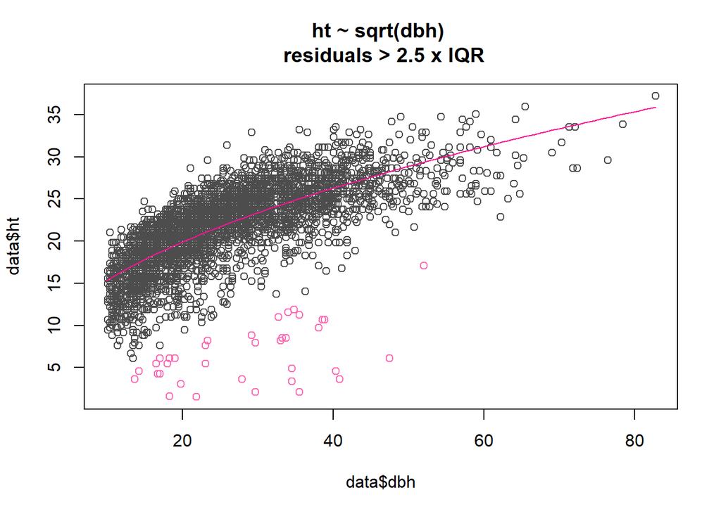

I also want to look at extreme changes in height. I’ll combine these two sets of outliers and look for height values that need fixing. I’m looking at outlier height increments that are 2 times above or below the IQR. Pink highlight indicates outlier values (for individual measurements as well as height increments). Salmon highlight indicates edited values with new value in parentheses.

```r
# New tree heights
new_ht <- tribble(
  ~tree_id,    ~year, ~ht,
  "1L80.3400", "08",  21,
  "1L80.3402", "13",  15.8,
  "2H40.3049", "08",  15,
  "2H40.3073", "18",  24,
  "2H40.3075", "13",  17,
  "2H80.3094", "18",  18,
  "2H80.3099", "18",  15,
  "2H80.3175", "18",  30,
  "2H80.4105", "13",  26,
  "2H80.4111", "13",  22,
  "3H40.1859", "18",  21,
  "3H80.3790", "13",  16,
  "3L80.3320", "08",  15,
  "3L80.3374", "18",  21,
  "4H80.4000", "18",  26.5,
  "4L40.3278", "18",  18,
  "4L40.3283", "08",  8.5,
  "C1.4146",   "18",  21,
  "C1.4197",   "13",  19,
  "C4.4676",   "18",  28,
  ) %>%
  mutate(
    year = factor(year, levels = c("init", "08", "13", "18"), ordered = TRUE)
  )
```

| tree_id | spp | ht_08 | ht_13 | ht_18 | dbh_seq | notes_08 | notes_13 | notes_18 | bear_seq | cr_seq | status_seq | cond_seq | p1 | p2 |
| --- | --- | --- | --- | --- | --- | --- | --- | --- | --- | --- | --- | --- | --- | --- |
| 1H40.1901 | SESE3 | 23.47 | 3.66 | NA | 27.43>27.94>NA | BA_ac_ft2=(H2^2*0.005454154)*5 | Top blown off, dead standing | NA | FALSE>FALSE>FALSE | 30>0>NA | 1>5>-5 | >3,7,31>3,7,31 | -19.81 | NA |
| 1H40.1907 | SESE3 | 20.42 | 21.33 | 17.07 | 28.7>32.51>38.1 | Tag Sequence Break | close to being on ground | NA | TRUE>TRUE>TRUE | 20>15>NA | 1>1>1 | >5,17>5,17 | 0.91 | -4.27 |
| 1H40.1908 | SESE3 | 4.27 | NA | NA | 16.76>16.51>NA | BROKEN TOP | dead, no sprouts | NA | FALSE>FALSE>FALSE | 5>0>NA | 31>5>5 | 3>> | NA | NA |
| 1H80.3581 | SESE3 | 14.93 | 13.11 | 4.57 | 13.72>13.97>14.22 | X | NA | NA | FALSE>FALSE>FALSE | 15>10>NA | 1>1>31 | >5,7>5,7 | -1.83 | -8.53 |
| 1H80.3589 | SESE3 | 17.37 | 6.1 | 6.71 | 13.3>13.46>13.21 | X | 2008 DBH probably read backwards | NA | FALSE>FALSE>FALSE | 10>5>NA | 1>1>1 | >2>2 | -11.28 | 0.61 |
| 1H80.3601 | SESE3 | 21.64 | 22.86 | 30.48 | 50.8>62.23>69.09 | X | NA | NA | TRUE>TRUE>TRUE | 35>30>NA | 1>1>1 | >4,5,17,26>4,5,17,26 | 1.22 | 7.62 |
| 1H80.3615 | PSMEM | 25.91 | 26.52 | 16.76 | 23.11>25.91>27.18 | X | NA | NA | FALSE>FALSE>FALSE | 20>10>NA | 1>1>1 | >3,4>3,4 | 0.61 | -9.75 |
| 1H80.3625 | SESE3 | 16.15 | 4.27 | 5.49 | 17.02>17.02>16.51 | X | NA | NA | FALSE>FALSE>FALSE | 15>10>NA | 1>31>1 | >3,4,8>3,4,8 | -11.89 | 1.22 |
| 1L80.3399 | SESE3 | 8.84 | 7.92 | NA | 29.21>29.72>28.96 | SEVERE ROT | NA | NA | TRUE>TRUE>TRUE | 5>10>NA | 1>1>1 | 3>6,7,12,17,26,3>6,7,3,33,17,26 | -0.91 | NA |
| 1L80.3400 | SESE3 | 14.02 (21) | 22.86 | NA | 36.32>37.34>36.83 | LEANER | check HTT data almost brock | NA | TRUE>TRUE>TRUE | 55>15>NA | 1>1>1 | >4,5,7,18,26>4,5,7,34,18,26 | 8.84 | NA |
| 1L80.3402 | SESE3 | 17.37 | 1.58 (15.8) | NA | 17.78>18.29>18.29 | X | NA | NA | FALSE>FALSE>FALSE | 15>10>NA | 1>1>1 | >5>4,5 | -15.79 | NA |
| 2H40.3041 | PSMEM | 18.9 | 19.51 | 26.82 | 19.3>20.83>24.13 | X | NA | NA | FALSE>FALSE>FALSE | 20>20>NA | 1>1>1 | >> | 0.61 | 7.31 |
| 2H40.3049 | SESE3 | 20.73 (15) | 14.32 | 12.5 | 14.99>16.76>21.84 | X | curling | NA | FALSE>FALSE>FALSE | 10>20>NA | 1>1>1 | >> | -6.40 | -1.83 |
| 2H40.3064 | SESE3 | 24.08 | 4.88 | NA | 34.29>34.54>NA | X | Broken tops dead; measured under bark | NA | TRUE>FALSE>FALSE | 15>0>NA | 1>6>6 | >8,3>8 | -19.20 | NA |
| 2H40.3071 | SESE3 | 26.21 | 3.66 | 4.57 | 39.12>40.89>40.39 | X | fork broke off; top broken | NA | TRUE>TRUE>TRUE | 30>10>NA | 1>31>31 | >3,6,17>3,6,17 | -22.55 | 0.91 |
| 2H40.3073 | SESE3 | 24.08 | 24.69 | 17.07 (24) | 33.78>39.12>52.07 | X | NA | NA | TRUE>TRUE>TRUE | 20>20>NA | 1>1>1 | >18>18 | 0.61 | -7.62 |
| 2H40.3075 | SESE3 | 19.51 | 9.14 (17) | 16.76 | 15.49>15.49>16.26 | X | retagged 4756; leaning into adjecent tree | NA | FALSE>FALSE>TRUE | 15>15>NA | 1>1>1 | >5,7>5,7,34,18 | -10.36 | 7.62 |
| 2H40.3079 | SESE3 | 19.81 | 14.93 | 14.32 | 12.7>13.72>15.49 | X | split below DBH | NA | FALSE>FALSE>FALSE | 10>15>NA | 1>1>1 | >3,8>3,8 | -4.88 | -0.61 |
| 2H40.3085 | SESE3 | 21.64 | 5.49 | 7.62 | 21.84>23.11>23.11 | X | Con Cd E=31 but it’s alive | NA | FALSE>TRUE>TRUE | 15>15>45 | 1>31>1 | >3,18>3,33,18 | -16.15 | 2.13 |
| 2H40.3088 | SESE3 | 17.07 | 11.89 | 11.58 | 19.81>21.08>22.86 | X | NA | NA | FALSE>FALSE>FALSE | 15>25>NA | 1>1>1 | >3,8>3,8 | -5.18 | -0.30 |
| 2H40.3092 | SESE3 | 21.03 | 23.77 | 6.1 | 38.61>41.15>47.5 | X | DBH wrapped under peeled bark; fresh BD 2/3 height of the tree | NA | FALSE>TRUE>TRUE | 25>25>NA | 1>1>1 | >19>3,19 | 2.74 | -17.68 |
| 2H80.3094 | SESE3 | 15.24 | 16.76 | 27.43 (18) | 22.61>25.91>28.7 | X | NA | NA | FALSE>FALSE>FALSE | 20>20>10 | 1>1>1 | >3>3 | 1.52 | 10.67 |
| 2H80.3099 | SESE3 | 14.02 | 15.24 | 7.92 (15) | 13.21>13.46>13.72 | X | NA | NA | FALSE>FALSE>FALSE | 25>30>40 | 1>1>1 | >1,7>1,7,33 | 1.22 | -7.31 |
| 2H80.3175 | PSMEM | 24.08 | 25.3 | 32.92 (30) | 23.11>26.42>29.21 | X | frass | NA | FALSE>FALSE>FALSE | 25>20>10 | 1>1>1 | >4>4 | 1.22 | 7.62 |
| 2H80.4105 | SESE3 | 24.38 | 18.29 (26) | 28.04 | 24.38>25.65>25.4 | X | NA | NA | FALSE>FALSE>FALSE | 30>10>NA | 1>1>1 | >> | -6.10 | 9.75 |
| 2H80.4111 | SESE3 | NA | 1.52 (22) | 21.94 | 21.59>21.84>21.84 | X | NA | NA | FALSE>FALSE>TRUE | 0>15>NA | 1>1>1 | >4>4,17 | NA | 20.42 |
| 2L40.3488 | SESE3 | 25.6 | 10.97 | 13.72 | 26.42>32.77>32.51 | FORK TOP | vigorous epicormic sprouting | NA | FALSE>FALSE>FALSE | 20>10>NA | 1>1>1 | >2,3,6,7>2,3,6,7 | -14.63 | 2.74 |
| 2L40.3489 | ALRU2 | 20.73 | 25.91 | 33.22 | 29.46>35.05>35.56 | X | NA | NA | FALSE>FALSE>FALSE | 30>20>NA | 1>1>1 | >>4 | 5.18 | 7.31 |
| 2L80.3729 | SESE3 | 8.23 | 8.53 | 11.58 | 33.02>33.78>34.04 | BROKEN TOP | NA | NA | FALSE>FALSE>FALSE | 10>25>25 | 1>1>1 | 3>3,6>3,6 | 0.30 | 3.05 |
| 3H40.1859 | SESE3 | 17.98 | 19.81 | 9.75 (21) | 23.88>29.72>38.1 | X | limbs raked | NA | FALSE>FALSE>FALSE | 30>25>25 | 1>1>1 | >> | 1.83 | -10.06 |
| 3H80.3790 | ALRU2 | 11.28 | 19.2 (16) | 19.81 | 20.32>21.08>21.34 | X | NA | NA | FALSE>FALSE>FALSE | 20>20>5 | 1>1>1 | >>25 | 7.92 | 0.61 |
| 3H80.3802 | PSMEM | 23.47 | 14.63 | NA | 30.23>30.48>30.73 | FORKED W/3803 | NA | NA | FALSE>FALSE>FALSE | 25>5>NA | 1>1>5 | >3>3 | -8.84 | NA |
| 3H80.3839 | SESE3 | 22.55 | 2.13 | NA | 29.21>29.72>29.97 | X | seven ft. tall; dowwned by wind above DBH; retagged; broken | re-tag 4775 | TRUE>TRUE>TRUE | 15>10>NA | 1>31>31 | >19,31>3,8,19 | -20.42 | NA |
| 3L40.1892 | SESE3 | 21.64 | 6.1 | 10.97 | 17.27>19.05>22.61 | X | NA | NA | FALSE>FALSE>FALSE | 20>60>60 | 1>1>1 | >3,6,8>3,6,8 | -15.54 | 4.88 |
| 3L40.3207 | SESE3 | 24.08 | 3.35 | NA | 30.73>34.54>33.78 | X | NA | broken top 6 ft | FALSE>FALSE>FALSE | 30>80>NA | 1>31>31 | >3,6,7>3,6,7 | -20.73 | NA |
| 3L40.3211 | PSMEM | 20.73 | 8.23 | NA | 23.11>23.37>23.37 | CROOK | dead! | NA | FALSE>FALSE>FALSE | 20>0>NA | 1>5>5 | >3,31>3 | -12.50 | NA |
| 3L80.3320 | SESE3 | 7.62 (15) | 16.15 | NA | 17.02>19.05>22.35 | X | NA | NA | FALSE>FALSE>FALSE | 5>40>NA | 1>1>1 | >4>4 | 8.53 | NA |
| 3L80.3370 | SESE3 | 21.94 | 17.07 | 17.68 | 25.4>27.69>28.45 | SESE3 | NA | NA | FALSE>FALSE>FALSE | 25>10>NA | 1>1>1 | >3>3,34 | -4.88 | 0.61 |
| 3L80.3374 | SESE3 | 19.2 | 20.73 | 10.97 (21) | 19.56>20.57>20.57 | X | severe rot | (suspect entry: ht originally recorded as 36.5) | TRUE>TRUE>TRUE | 10>5>NA | 1>1>1 | >1,17>1,17 | 1.52 | -9.75 |
| 4H40.3959 | SESE3 | 15.54 | 7.62 | NA | 13.21>14.22>15.24 | Top broken during operations | broken | NA | FALSE>FALSE>FALSE | 10>50>NA | 1>1>1 | >3>3 | -7.92 | NA |
| 4H80.3975 | PSMEM | 18.9 | 13.72 | NA | 19.81>19.56>NA | X | NA | NA | FALSE>FALSE>FALSE | 15>0>NA | 1>6>6 | >3> | -5.18 | NA |
| 4H80.3992 | PSMEM | 27.13 | 21.03 | 21.33 | 39.37>40.39>40.64 | X | frass | NA | FALSE>FALSE>FALSE | 25>30>NA | 1>1>1 | >3,4>3,4 | -6.10 | 0.30 |
| 4H80.4000 | PSMEM | 23.77 | 25.91 | 16.46 (26.5) | 25.91>28.45>29.97 | X | frass | NA | FALSE>FALSE>FALSE | 20>20>15 | 1>1>1 | >4>4 | 2.13 | -9.45 |
| 4H80.4005 | SESE3 | 11.28 | 11.89 | NA | 35.56>34.8>34.29 | BROKEN TOP | NA | NA | TRUE>FALSE>FALSE | 5>0>NA | 1>6>6 | 3>3>3 | 0.61 | NA |
| 4H80.4011 | SESE3 | 5.49 | 6.1 | NA | 18.03>18.29>17.78 | BROKEN TOP | NA | NA | FALSE>FALSE>FALSE | 10>10>NA | 1>1>1 | 3>3>3,33 | 0.61 | NA |
| 4H80.4027 | PSMEM | 17.68 | 12.8 | NA | 14.22>14.48>NA | X | NA | NA | FALSE>FALSE>FALSE | 15>0>NA | 1>5>5 | >3> | -4.88 | NA |
| 4L40.3255 | SESE3 | 17.07 | 3.66 | NA | 20.07>13.72>14.48 | X | tree split in half | NA | TRUE>FALSE>TRUE | 20>40>60 | 1>31>31 | >3,6,8>3,6,8,18 | -13.41 | NA |
| 4L40.3262 | SESE3 | 15.85 | 6.1 | NA | 16.51>17.02>18.8 | X | NA | NA | TRUE>TRUE>TRUE | 15>50>60 | 1>1>31 | >3,7,17>3,7,17 | -9.75 | NA |
| 4L40.3278 | PSMEM | 22.25 | 16.76 | 24.99 (18) | 39.12>41.15>42.16 | X | broken top; frass | NA | FALSE>FALSE>FALSE | 25>10>10 | 1>1>1 | >3,4>3,4 | -5.49 | 8.23 |
| 4L40.3283 | PSMEM | 24.08 (8.5) | 8.53 | NA | 33.27>33.27>NA | Blow down | frass; broken top; dead | NA | FALSE>FALSE>FALSE | 30>0>NA | 31>5>5 | >> | -15.54 | NA |
| C1.4164 | PSMEM | 21.33 | 21.94 | 11.28 | 18.03>18.8>19.05 | NA | NA | NA | FALSE>FALSE>FALSE | 15>15>NA | 1>1>1 | >4>4 | 0.61 | -10.67 |
| C1.4197 | PSMEM | 18.59 | 24.99 (19) | 20.12 | 18.8>19.56>19.56 | NA | NA | NA | FALSE>FALSE>FALSE | 15>25>NA | 1>1>1 | >3,4>3,4 | 6.40 | -4.88 |
| C1.4204 | SESE3 | 10.67 | 10.67 | 10.67 | 38.86>38.86>38.61 | SNAGTOP | NA | NA | TRUE>TRUE>TRUE | 10>15>NA | 1>1>1 | 2>2,7,18>3,4,18 | 0.00 | 0.00 |
| C3.4444 | SESE3 | 2.13 | NA | NA | 35.56>35.31>NA | THIS TREE IS A BLOW DOWN WITH A BASE STILL TALL ENOUGH TO TAKE A DBH. HOWEVER, THE TREE IS SOMEWHAT SPLINTERED AT BREAST HEIGHT SO THE DBH WAS ESTIMATED WITH THE AID OF THE D TAPE. THE TREE HAS SEVERA… | stripped off wood around DBH (5) | Dead, Downed | TRUE>TRUE>TRUE | 50>0>NA | 31>5>5 | >18>18,31 | NA | NA |
| C3.4530 | PSMEM | 21.64 | 3.05 | NA | 19.3>19.81>19.3 | NA | NA | Dead | FALSE>FALSE>FALSE | 20>4>NA | 1>31>5 | >> | -18.59 | NA |
| C4.4608 | PSMEM | 23.16 | 24.99 | 19.81 | 38.1>39.62>40.89 | NA | NA | NA | FALSE>FALSE>FALSE | 20>20>15 | 1>1>1 | >3,4>3,4 | 1.83 | -5.18 |
| C4.4676 | SESE3 | 25.91 | 27.43 | 23.47 (28) | 38.86>42.67>50.04 | NA | NA | NA | TRUE>TRUE>TRUE | 40>20>30 | 1>1>1 | >17>17 | 1.52 | -3.96 |

```r
# Update datasets with new heights
d_l <- rows_update(d_l, new_ht, by = c("tree_id", "year"))
p_h <- filter(d_l, year > "init")
```

Our plot of height outliers doesn’t change much, but if we include only status 1, unbroken trees, then our residuals are more homogenous. Filtering like this omits 836 observations over the 3 post harvest measurements. If we remove non-status-one and broken trees *under 12 m*, then 369 trees are omitted and most of the outliers are removed.

Next, I’ll look at the proportion of trees that have height measurements, but it is worth noting here that for regression purposes there are 3537 observations *with both dbh and height measurements* (of 4591 total). Of the observations with full measurements, filtering, as above, removes 304 and 82 observations, respectively.

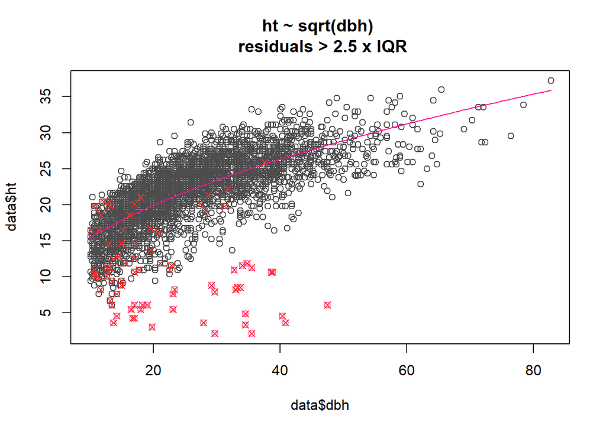

```r
p_h %>% plot_ht(mag = 2.5)

# What trees are ommited if we remove broken trees
p_h %>%
  filter(
    !is.na(ht * dbh),
    status != 1 |
    get_cond(c(2, 3)) & ht < 12
  ) %>%
  select(dbh, ht) %>%
  points(col = "firebrick1", pch = 4)
```

```r
p_h %>%
  filter(
    !is.na(ht * dbh),
    status != 1 | get_cond(c(2, 3))) %>%
  nrow()
```

```
## [1] 304
```

```r
p_h %>%
  filter(
    !is.na(ht * dbh),
    status != 1 | (get_cond(c(2, 3)) & ht < 12)) %>%
  nrow()
```

```
## [1] 82
```

### Missing heights

Heights for 2018 seem to only have been taken for a sample of the trees (643 of 1505). I’m not sure how these were selected, so tree selection may be a source of bias. I checked what proportion of heights were measured for plots and treatments. 35 - 70% of heights were sampled for each treatment and 17% - 100% of each plot has height measurements.

For comparison purposes, I’ll summarize height across measurement periods *only for tree ids that have height measurements in 2018*, with the understanding that the height related sampling error may introduce bias especially at the plot level, where sampling intensity ranged from 0.17 to 1.

```r
# do any target trees have missing heights? If so, how many
any(nrow(filter(d_l, status %in% c(1, 2, 3, 15, 16), is.na(ht))))
```

```
## [1] TRUE
```

```r
nrow(filter(d_l, status %in% c(1, 2, 3, 15, 16), is.na(ht)))
```

```
## [1] 1507
```

```r
# proportion of (target) trees that have height measurements each period
filter(p_h, status %in% c(1, 2, 3, 15, 16)) %>%
  group_by(year, measured = !is.na(ht)) %>%
  summarise(n = n()) %>%
  mutate(freq = n / sum(n), .keep = "unused") %>%
  filter(measured)
```

```
## # A tibble: 3 x 3
## # Groups:   year [3]
##   year  measured  freq
##   <ord> <lgl>    <dbl>
## 1 08    TRUE     0.983
## 2 13    TRUE     0.998
## 3 18    TRUE     0.526
```

```r
# what proportion of trees in 2018 by treatment and plot DO have height data?
filter(d_l, status %in% c(1, 2, 3, 15, 16), year == "18") %>%
  group_by(plot, measured = !is.na(ht)) %>%
  summarise(n = n()) %>%
  mutate(freq = round(n / sum(n), 2)) %>%
  filter(measured) %>%
  select(plot, freq)
```

```
## # A tibble: 20 x 2
## # Groups:   plot [20]
##    plot   freq
##    <chr> <dbl>
##  1 1H40   1
##  2 1H80   0.99
##  3 1L40   0.21
##  4 1L80   0.35
##  5 2H40   0.97
##  6 2H80   0.94
##  7 2L40   1
##  8 2L80   0.27
##  9 3H40   0.34
## 10 3H80   0.36
## 11 3L40   0.48
## 12 3L80   0.46
## 13 4H40   0.43
## 14 4H80   0.4
## 15 4L40   0.33
## 16 4L80   0.28
## 17 C1     1
## 18 C2     0.37
## 19 C3     0.17
## 20 C4     0.4
```

```r
filter(d_l, status %in% c(1, 2, 3, 15, 16), year == "18") %>%
  group_by(treatment, measured = !is.na(ht)) %>%
  summarise(n = n()) %>%
  mutate(freq = round(n / sum(n), 2)) %>%
  filter(measured) %>%
  select(treatment, freq)
```

```
## # A tibble: 5 x 2
## # Groups:   treatment [5]
##   treatment  freq
##   <chr>     <dbl>
## 1 C          0.47
## 2 H40        0.64
## 3 H80        0.7
## 4 L40        0.56
## 5 L80        0.35
```

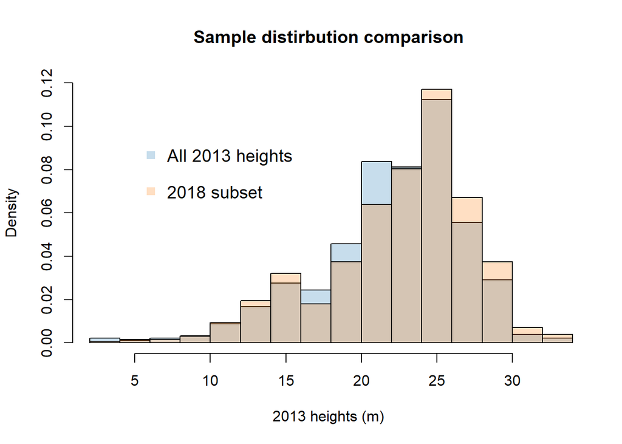

My plan is to calculate height metrics (for comparison) based just on those trees which have heights measured in 2018. This means that I would only be looking at 1911 of the 3488 total height measurements (status 1 trees only).

There are 14 different trees which are missing heights for 2008 and have heights in 2013 and 2018. I can deal with these values in one of the following ways:

- Simply omit these observations from the analysis
- Manually estimate using average increments for species and treatment
- Fit a linear model including dbh, treatment, ht_13 and ht_18, bear.
- Fit separate models (mixed model?)

### Dominant trees missing heights

I need to check to see that there are heights recorded for all **dominant trees** at each observation period, otherwise we are not really getting dominant height. First I’ll check to see how many heights are missing for dominant trees (top 4 dbh per plot == 50 tph).

There are 12 plots that are missing dominant tree height data and all of them are in 2018—a total of 26 trees. It also looks like there are very few trees of the same species/plot to predict missing values from in some plots. I’ve included the average dbh of the missing tree as well as the range of dbh for which heights are available by plot/species.

```r
p_h %>%
  group_by(plot, year) %>%
  filter(status == 1, !get_cond(c(2, 3))) %>%
  mutate(rank = rank(-dbh, ties.method = "min")) %>%
  group_by(plot, year, spp) %>%
  summarize(
    ht_na = sum(is.na(ht) & rank <= 4),
    na_dbh_mean = paste(
      mean(dbh[rank <= 4 & is.na(ht)], na.rm = TRUE), collapse = ", "),
    have_ht = sum(!is.na(ht)),
    have_dbh_range = paste(
      range(dbh[!is.na(ht)], na.rm = TRUE), collapse = ", ")
  ) %>%
  filter(ht_na > 0) %>%
  color_groups()
```

| plot | year | spp | ht_na | na_dbh_mean | have_ht | have_dbh_range |
| --- | --- | --- | --- | --- | --- | --- |
| 1L40 | 18 | PSMEM | 4 | 50.038 | 3 | 37.592, 39.37 |
| 1L80 | 18 | PSMEM | 1 | 53.34 | 13 | 19.558, 41.148 |
| 1L80 | 18 | SESE3 | 1 | 63.754 | 9 | 25.4, 58.166 |
| 2H40 | 18 | SESE3 | 1 | 57.404 | 17 | 16.256, 71.882 |
| 2L80 | 18 | PSMEM | 1 | 46.228 | 13 | 18.542, 47.498 |
| 2L80 | 18 | SESE3 | 1 | 53.6 | 5 | 33.528, 44.704 |
| 3H40 | 18 | SESE3 | 3 | 63.8386666666667 | 6 | 23.114, 58.42 |
| 3L40 | 18 | PSMEM | 1 | 50.8 | 7 | 33.782, 44.958 |
| 4H40 | 18 | PSMEM | 2 | 44.704 | 10 | 21.59, 48.514 |
| 4H80 | 18 | PSMEM | 1 | 55.118 | 7 | 23.368, 51.816 |
| 4L40 | 18 | PSMEM | 2 | 54.61 | 2 | 36.322, 41.656 |
| 4L80 | 18 | PSMEM | 2 | 50.419 | 6 | 25.908, 59.69 |
| 4L80 | 18 | SESE3 | 1 | 51.816 | 5 | 16.51, 47.752 |
| C2 | 18 | PSMEM | 2 | 44.831 | 11 | 14.732, 45.72 |
| C3 | 18 | PISI | 1 | 64.008 | 0 | Inf, -Inf |
| C3 | 18 | PSMEM | 1 | 48.514 | 10 | 15.24, 36.068 |
| C3 | 18 | SESE3 | 1 | 51.054 | 2 | 10.414, 48.26 |

I’m curious about dominant trees in general, are they also the tallest trees? Out of the 240 dominant (diameter) trees over three measurement periods, 66 of them do not rank in the top 9 trees (by plot) in height. I’m excluding broken/dead tops and missing heights. This makes me wonder if we are accurately characterizing dominant trees. Perhaps these trees were once, but are no longer dominant.

```r
p_h %>%
  group_by(plot, year) %>%
  filter(status == 1, !get_cond(c(2, 3))) %>%
  mutate(
    tallest = rank(-ht, ties.method = "min"),
    widest = rank(-dbh, ties.method = "min")
  ) %>%
  filter(widest <= 4, tallest > 9, !is.na(ht)) %>%
  select(-c(azi, h_dist, treatment, cc, rot, status)) %>%
  group_by(tree_id) %>%
  color_groups()
```

| plot | tree_id | spp | year | dbh | ht | cr | bear | notes | cond | tallest | widest |
| --- | --- | --- | --- | --- | --- | --- | --- | --- | --- | --- | --- |
| 1H40 | 1H40.3032 | SESE3 | 18 | 54.864 | 27.73545 | NA | TRUE | NA | 17 | 10 | 2 |
| 1H80 | 1H80.3601 | SESE3 | 08 | 50.800 | 21.63974 | 35 | TRUE | X |  | 31 | 2 |
| 1H80 | 1H80.3601 | SESE3 | 13 | 62.230 | 22.85888 | 30 | TRUE | NA | 4,5,17,26 | 39 | 2 |
| 1H80 | 1H80.3612 | SESE3 | 13 | 48.260 | 21.03017 | 20 | TRUE | NA | 19,26 | 49 | 4 |
| 1H80 | 1H80.3612 | SESE3 | 18 | 60.960 | 25.90674 | NA | TRUE | NA | 19,26 | 27 | 4 |
| 1L40 | 1L40.3658 | PSMEM | 08 | 47.498 | 21.94453 | 20 | FALSE | SHORT TREE |  | 24 | 1 |
| 1L40 | 1L40.3658 | PSMEM | 13 | 49.276 | 23.77324 | 25 | FALSE | double tree | 1,4,22 | 16 | 1 |
| 1L40 | 1L40.3674 | SESE3 | 08 | 38.862 | 25.60195 | 30 | FALSE | X |  | 11 | 4 |
| 1L80 | 1L80.3403 | SESE3 | 08 | 52.070 | 25.60195 | 25 | TRUE | X |  | 11 | 2 |
| 1L80 | 1L80.3451 | SESE3 | 08 | 53.848 | 24.38281 | 45 | TRUE | Tag Sequence Break |  | 23 | 1 |
| 1L80 | 1L80.3451 | SESE3 | 13 | 60.198 | 25.90674 | 30 | TRUE | Rot at base; 3451 | 1,17,26 | 22 | 1 |
| 1L80 | 1L80.3464 | SESE3 | 13 | 53.086 | 27.73545 | 35 | FALSE | NA |  | 11 | 3 |
| 2H40 | 2H40.3060 | SESE3 | 13 | 50.292 | 24.99238 | 15 | FALSE | NA |  | 14 | 2 |
| 2H40 | 2H40.3067 | SESE3 | 18 | 58.420 | 26.51631 | NA | TRUE | NA | 17 | 13 | 3 |
| 2H40 | 2H40.3080 | SESE3 | 18 | 59.182 | 24.68760 | NA | TRUE | NA | 19 | 15 | 2 |
| 2H40 | 2H40.3086 | SESE3 | 08 | 57.658 | 25.60195 | 25 | FALSE | X |  | 10 | 2 |
| 2H40 | 2H40.3086 | SESE3 | 13 | 64.770 | 25.60195 | 20 | FALSE | frass | 4 | 11 | 1 |
| 2H80 | 2H80.3130 | SESE3 | 08 | 52.832 | 24.07803 | -999 | TRUE | X |  | 11 | 1 |
| 2H80 | 2H80.3149 | SESE3 | 13 | 53.848 | 26.51631 | 25 | FALSE | NA |  | 11 | 2 |
| 2H80 | 2H80.3159 | SESE3 | 18 | 54.610 | 28.04023 | 25 | FALSE | NA |  | 18 | 4 |
| 2L40 | 2L40.3470 | PSMEM | 08 | 35.560 | 21.94453 | 30 | FALSE | X |  | 25 | 4 |
| 2L40 | 2L40.3510 | PSMEM | 13 | 39.878 | 26.82109 | 25 | FALSE | FRASS |  | 14 | 4 |
| 2L40 | 2L40.3520 | PSMEM | 08 | 37.338 | 24.07803 | 25 | FALSE | X |  | 18 | 3 |
| 2L40 | 2L40.3520 | PSMEM | 13 | 40.132 | 26.82109 | 20 | FALSE | FRASS |  | 14 | 3 |
| 2L40 | 2L40.3522 | PSMEM | 08 | 38.354 | 24.38281 | 20 | FALSE | X |  | 13 | 2 |
| 2L40 | 2L40.3522 | PSMEM | 13 | 42.672 | 24.99238 | 25 | FALSE | FRASS | 1,4 | 20 | 1 |
| 2L40 | 2L40.3522 | PSMEM | 18 | 44.196 | 27.12588 | NA | FALSE | NA | 1,4,22 | 16 | 3 |
| 2L80 | 2L80.3683 | PSMEM | 08 | 38.862 | 23.46845 | 25 | FALSE | X |  | 10 | 2 |
| 2L80 | 2L80.3723 | SESE3 | 08 | 36.322 | 21.94453 | 25 | TRUE | X |  | 19 | 3 |
| 2L80 | 2L80.3726 | SESE3 | 13 | 40.132 | 24.99238 | 25 | FALSE | NA |  | 10 | 4 |
| 3H40 | 3H40.1844 | SESE3 | 08 | 46.736 | 24.07803 | 30 | TRUE | X |  | 14 | 3 |
| 3H40 | 3H40.1882 | SESE3 | 13 | 52.324 | 24.68760 | 20 | TRUE | NA | 18 | 14 | 4 |
| 3H80 | 3H80.3838 | SESE3 | 13 | 39.116 | 25.29717 | 25 | FALSE | NA |  | 14 | 4 |
| 3H80 | 3H80.3846 | SESE3 | 13 | 51.054 | 25.60195 | 20 | TRUE | frass | 1,17 | 12 | 1 |
| 3H80 | 3H80.3903 | PSMEM | 08 | 36.322 | 24.07803 | 25 | FALSE | X |  | 10 | 3 |
| 3L40 | 3L40.1900 | PSMEM | 08 | 39.370 | 20.72539 | 30 | TRUE | X |  | 26 | 4 |
| 3L40 | 3L40.3201 | SESE3 | 08 | 41.910 | 20.11582 | 25 | TRUE | Tag Sequence Break |  | 29 | 2 |
| 3L80 | 3L80.3304 | PSMEM | 08 | 37.846 | 23.16367 | 25 | FALSE | X |  | 13 | 2 |
| 3L80 | 3L80.3316 | PSMEM | 08 | 35.306 | 22.85888 | 30 | FALSE | X |  | 20 | 4 |
| 4H40 | 4H40.3926 | SESE3 | 08 | 38.608 | 24.07803 | 30 | TRUE | LOOKS GREAT |  | 12 | 1 |
| 4H40 | 4H40.3926 | SESE3 | 13 | 44.704 | 25.29717 | 20 | FALSE | BD healed over |  | 14 | 1 |
| 4H40 | 4H40.3946 | PSMEM | 08 | 35.306 | 23.77324 | 25 | FALSE | SHORT TREE |  | 13 | 3 |
| 4H40 | 4H40.3946 | PSMEM | 13 | 41.402 | 25.60195 | 20 | TRUE | FRASS | 4,18 | 12 | 2 |
| 4L40 | 4L40.3250 | SESE3 | 08 | 42.926 | 18.89668 | 20 | FALSE | X |  | 28 | 3 |
| 4L80 | 4L80.1967 | PSMEM | 08 | 41.656 | 23.16367 | 35 | FALSE | X |  | 13 | 4 |
| 4L80 | 4L80.1967 | PSMEM | 13 | 44.196 | 24.38281 | 20 | FALSE | frass | 1,4 | 26 | 3 |
| C1 | C1.4169 | SESE3 | 08 | 54.864 | 24.07803 | 35 | TRUE | NA |  | 20 | 1 |
| C1 | C1.4179 | SESE3 | 08 | 45.466 | 24.38281 | 35 | FALSE | NA |  | 18 | 4 |
| C1 | C1.4179 | SESE3 | 18 | 53.848 | 28.64980 | NA | FALSE | NA |  | 14 | 2 |
| C1 | C1.4180 | SESE3 | 18 | 52.324 | 28.34502 | NA | FALSE | NA |  | 17 | 4 |
| C1 | C1.4209 | SESE3 | 08 | 53.340 | 24.68760 | 25 | FALSE | TRIPLE TOP |  | 13 | 3 |
| C1 | C1.4209 | SESE3 | 13 | 56.896 | 25.60195 | 25 | FALSE | triple top | 1,4,6 | 17 | 2 |
| C1 | C1.4209 | SESE3 | 18 | 61.722 | 27.73545 | NA | FALSE | NA | 1,4,6 | 19 | 1 |
| C2 | C2.4276 | PISI | 08 | 45.466 | 25.60195 | 35 | TRUE | NA |  | 11 | 1 |
| C2 | C2.4311 | PSMEM | 08 | 40.386 | 21.33496 | 30 | FALSE | NA |  | 52 | 4 |
| C2 | C2.4311 | PSMEM | 13 | 43.942 | 26.51631 | 15 | FALSE | NA | 4 | 14 | 2 |
| C2 | C2.4322 | PSMEM | 08 | 42.164 | 23.46845 | 20 | FALSE | NA |  | 29 | 2 |
| C2 | C2.4322 | PSMEM | 13 | 43.434 | 25.29717 | 30 | FALSE | NA | 1 | 24 | 3 |
| C3 | C3.4446 | SESE3 | 08 | 41.910 | 18.28711 | 25 | FALSE | NA |  | 121 | 3 |
| C3 | C3.4446 | SESE3 | 13 | 45.974 | 23.46845 | 30 | FALSE | old DBH |  | 37 | 2 |
| C3 | C3.4518 | PSMEM | 13 | 45.974 | 25.90674 | 30 | FALSE | NA | 4 | 11 | 2 |
| C4 | C4.4601 | SESE3 | 08 | 45.212 | 24.07803 | 30 | FALSE | SPLIT BELOW DBH |  | 23 | 1 |
| C4 | C4.4602 | SESE3 | 18 | 44.450 | 25.60195 | 20 | FALSE | NA | 4 | 14 | 4 |
| C4 | C4.4608 | PSMEM | 08 | 38.100 | 23.16367 | 20 | FALSE | NA |  | 31 | 4 |
| C4 | C4.4648 | SESE3 | 18 | 44.704 | 23.77324 | NA | TRUE | healing well from bear damage | 19 | 18 | 3 |
| C4 | C4.4706 | PSMEM | 13 | 38.862 | 24.68760 | 20 | FALSE | NA |  | 32 | 4 |

## Defining live/dead trees

Status and condition codes provided do not necessarily define mortality, because a broken tree, depending on species may still be alive or dead. I’ll define dead trees as:

1. snags or down snags (status -9 to -5, and 5 to 9)
2. trees broken below dbh and uprooted trees (status 30, 32)
3. any non-sprouting species broken above dbh (status 31)
4. any sprouting species broken below 3 meters

```r
d_l <- d_l %>%
  mutate(
    live = case_when(
      status %in% c(5:9, -5:-9)                                  ~ FALSE,
      status %in% c(30, 32)                                      ~ FALSE,
      (spp %in% c("PSMEM", "PISI") & status == 31)               ~ FALSE,
      (spp %in% c("SESE3", "ALRU") & status == 31 & ht < 3)      ~ FALSE,
      (spp %in% c("SESE3", "ALRU") & status == 31 & lag(ht) < 3) ~ FALSE,
      TRUE                                                       ~ TRUE
    )
  )

# Do any trees go from being dead to being alive?
nrow(filter(group_by(d_l, tree_id), any(!live & lead(live))))
```

```
## [1] 0
```

```r
# update post-harvest data
p_h <- filter(d_l, year > "init")
```

## Define diameter increment

I looked at increment earlier to try to suss out bad dbh entries. Here I will formally add annual diameter increment to the long-form dataset. Each observation will be associated with a p1 and p2 increment. These are 5-year increments. Should I divide this number by 5?

```r
# Add increment data and update post-harvest data
d_l <- d_l %>%
  group_by(tree_id) %>%
  mutate(
    inc_1 = nth(lead(dbh) - dbh, 2, order_by = year),
    inc_2 = nth(lead(dbh) - dbh, 3, order_by = year)
  ) %>%
  ungroup()

p_h <- filter(d_l, year > "init")
```

## Explore bear damage

# Calculate summary statistics

I’m making the assumption now that all trees recorded as cut were alive in the initial conditions. For all of the following I use trees with status 1, 2, 3, 15, 16. Fifteen and 16 are cut trees, but in the long data format, they only occur on entries where year = “init” so they do not affected other periods. Status 1, 2 and 3 represent second-growth, advanced regen, and old-growth, respectively.

Generally, the `summarise()` command in each section defines the output of a given measure. The `mutate()` command is also used for calculating new columns. Calculations are done by grouping levels (generally by treatment, by year).

```r
# I'll store all my metrics in this list
measures <- list()
```

## Density

I’ll look at a quick summary of quartiles of the number of tree observations by plot for each year. Initial plots had between 83 and 164 observations and subsequent years are roughly parallel. Density is being calculated for all live trees, including those broken above dbh.

```r
d_l %>%
  filter(status %in% c(1, 2, 3, 15, 16, 31)) %>%
  group_by(year, plot) %>%
  summarize(n = n()) %>%
  summarize(as_tibble_row(quantile(n)))
```

```
## # A tibble: 4 x 6
##   year   `0%` `25%` `50%` `75%` `100%`
##   <ord> <dbl> <dbl> <dbl> <dbl>  <dbl>
## 1 init     83 124   134.  143.     164
## 2 08       26  40.8  84   108.     147
## 3 13       21  35.5  79    94      117
## 4 18       20  33.5  74.5  84.5     92
```

```r
# unused <- function(data, by_species = FALSE) {
#   data %>%
#     filter(live | status %in% c(15, 16)) %>%
#     group_by(!!!group_vars(by_species)) %>%
#     # expansion factor 12.5, over 4 replicates
#     summarise(density = n() * 12.5 / 4, n_density = n())
# }


measures$density <- function(data, species) {
  if(is.null(species)) species <- unique(data$spp)
  data %>%
    filter(spp %in% species, live | status %in% c(15, 16)) %>%
    group_by(treatment, year, plot) %>%
    # expansion factor 12.5 (12.5 * .08 = 1 ha)
    summarise(density_plot = n() * 12.5, n_density = n()) %>%
    summarise(
      val_density = mean(density_plot),
      n_density = sum(n_density),
      sd_density = sd(density_plot)
    )
}
```

## Mortality

New mortality here is ascribed to observations of the current period which were alive in the previous period and are not alive in the current period and reported in tph. Currently, this is undefined for the first period (“init”) and is zero for “08” (because “init” and “08” are really only one observation). The values for 2013 and 2018 record the new mortality in the previous period, ie: 08-13 and 13-18, respectively.

```r
measures$mort <- function(data, species) {
  if(is.null(species)) species <- unique(data$spp)
  data %>%
    filter(spp %in% species) %>%
    group_by(tree_id) %>%
    mutate(mort = ((live == FALSE) * (lag(live) == TRUE)) > 0) %>%
    group_by(year, treatment, plot) %>%
    summarize(mort_plot = sum(mort) * 12.5, n_mort = n()) %>%
    summarize(
      val_mort = mean(mort_plot),
      n_mort = sum(n_mort),
      sd_mort = sd(mort_plot)
    )
}
```

## dbh

Dbh will be calculated based on all live trees, including those broken above dbh and with broken and dead tops (most of these are SESE and assumed to be alive).

```r
measures$dbh <- function(data, species) {
  if(is.null(species)) species <- unique(data$spp)
  data %>%
    filter(spp %in% species, live | status %in% c(15, 16)) %>%
    group_by(treatment, year) %>%
    summarise(
      val_dbh = mean(dbh),
      n_dbh = n(),
      sd_dbh = sd(dbh, na.rm = TRUE)
    )
}


# unused <- d_l %>%
#   filter(status %in% c(1, 2, 3, 15, 16)) %>%
#   group_by(plot, year) %>%
#   slice_max(order_by = dbh, n = 4, with_ties = FALSE) %>%
#   group_by(spp, treatment, year) %>%
#   summarise(dom_dbh = mean(dbh), n_dom_dbh = n())

measures$dom_dbh <- function(data, species) {
  if(is.null(species)) species <- unique(data$spp)
  data %>%
    filter(live | status %in% c(15, 16)) %>%
    group_by(plot, year) %>%
    slice_max(order_by = dbh, n = 4, with_ties = FALSE) %>%
    filter(spp %in% species) %>%
    group_by(treatment, year) %>%
    summarise(
      val_dom_dbh = mean(dbh),
      n_dom_dbh = n(),
      sd_dom_dbh = sd(dbh))
}
```

## Heights

Heights will be determined using only trees with unbroken, live crowns.

Because there are about 14 observations in 2008 and 2013 that do not have height measurements, I am omitting these from analysis for now. Also, I am only looking at trees that have height measurements in 2018. This means that of the 3,538 total height observations, I am only looking at 1,929 over the the three measurement periods.

For dominant heights, I am using dominant dbh trees *not including broken and dead tops*. Not all of these have heights. For this reason, there are fewer than 4 trees per plot.

```r
# get ids of trees that have heights in 2018
ht_id_2018 <- filter(d_l, year == "18", !is.na(ht)) %>% pull(tree_id)

# average height I AM OMMITING MISSING HEIGHT MEASUREMENTS.
measures$ht <- function(data, species) {
  if(is.null(species)) species <- unique(data$spp)
  data %>%
    filter(
      spp %in% species,
      live | status %in% c(15, 16),
      !get_cond(c(2, 3)),
      tree_id %in% ht_id_2018,
      !is.na(ht)
    ) %>%
  group_by(treatment, year) %>%
  summarise(
    val_ht = mean(ht),
    n_ht = n(),
    sd_ht = sd(ht)
  )
}

# unused <- d_l %>%
#   filter(
#     live | status %in% c(15, 16),
#     !get_cond(c(2, 3)),
#     tree_id %in% ht_id_2018,
#     !is.na(ht)) %>%
#   group_by(spp, treatment, year) %>%
#   summarise(ht = mean(ht), n_ht = n())

# Dominant height
# I AM CALCULATING DOM HEIGHT ONLY FROM THOSE AVAILABLE
measures$dom_ht <- function(data, species) {
  if(is.null(species)) species <- unique(data$spp)
  data %>%
    filter(
      live | status %in% c(15, 16),
      !get_cond(2, 3),
      tree_id %in% ht_id_2018
    ) %>%
    group_by(plot, year) %>%
    slice_max(order_by = ht, n = 4, with_ties = FALSE) %>%
    filter(spp %in% species) %>%
    group_by(treatment, year) %>%
    summarise(
      val_dom_ht = mean(ht, na.rm = TRUE),
      n_dom_ht = sum(!is.na(ht)),
      sd_dom_ht = sd(ht, na.rm = TRUE)
    )
}
```

## Basal Area

Basal area, similar to density will be calculated for all live trees.

```r
# measures$ba <- d_l %>%
#   filter(live | status %in% c(15, 16)) %>%
#   group_by(treatment, year) %>%
#   summarise(ba = sum(dbh^2 * pi / 40000) * (12.5 / 4), n_ba = n())

measures$ba <- function(data, species) {
  if(is.null(species)) species <- unique(data$spp)
  data %>%
    filter(spp %in% species, live | status %in% c(15, 16)) %>%
    group_by(treatment, year, plot) %>%
    summarise(
      ba_plot = sum(dbh^2 * pi / 40000, na.rm = TRUE) * 12.5,
      n_ba = n()
    ) %>%
    summarize(
      val_ba = mean(ba_plot),
      n_ba = sum(n_ba),
      sd_ba = sd(ba_plot)
    )
}
```

## SDI

For SDI, I use the same trees that were used for basal area and density: all standing trees (broken or not) that are taller than breast height.

```r
# do any target trees have missing dbh?
any(nrow(filter(d_l, status %in% c(1, 2, 3, 15, 16), is.na(dbh))))
```

```
## [1] FALSE
```

```r
measures$sdi <- function(data, species) {
  if(is.null(species)) species <- unique(data$spp)
  data %>%
    filter(spp %in% species, live | status %in% c(15, 16)) %>%
    group_by(treatment, year, plot) %>%
    summarise(
      sdi_plot = sum(12.5 * (dbh * 0.04)^1.605, na.rm = TRUE),
      n_sdi = n()
    ) %>%
    summarize(
      val_sdi = mean(sdi_plot),
      n_sdi = sum(n_sdi),
      sd_sdi = sd(sdi_plot)
    )
}
```

# Initial summary tables

## All species

```r
get_measures(d_l) %>%
  make_summary() %>%
  kbl() %>%
  kable_classic(full_width = FALSE, html_font = "Garamond") %>%
  add_header_above(c(" " = 2, "Treatment" = 5)) %>%
  collapse_rows(columns = 1, valign = "top")
```

| measure | year | Treatment C | Treatment H40 | Treatment H80 | Treatment L40 | Treatment L80 |
| --- | --- | --- | --- | --- | --- | --- |
| Basal area (m<sup>2</sup>/ha) | init | 65.0 (5.1) | 75.0 (15.7) | 73.7 (7.5) | 71.6 (4.0) | 68.2 (12.4) |
|  | 08 | 65.0 (5.0) | 33.5 (7.2) | 58.4 (5.8) | 31.8 (0.8) | 54.6 (10.6) |
|  | 13 | 69.2 (3.8) | 39.8 (8.8) | 65.9 (7.9) | 35.7 (4.5) | 62.3 (12.5) |
|  | 18 | 71.7 (3.5) | 47.6 (14.7) | 75.9 (9.6) | 42.3 (6.4) | 71.1 (15.5) |
| dbh (cm) | init | 21.6 (8.2) | 22.7 (9.3) | 22.5 (8.5) | 21.9 (7.7) | 20.6 (8.1) |
|  | 08 | 21.6 (8.2) | 27.2 (11.0) | 22.4 (8.9) | 30.4 (7.1) | 24.2 (8.2) |
|  | 13 | 24.1 (9.1) | 31.8 (12.4) | 25.6 (10.4) | 34.6 (7.5) | 26.4 (9.1) |
|  | 18 | 27.5 (10.4) | NA (14.1) | 28.2 (12.3) | 38.7 (8.6) | NA (10.3) |
| Density (tph) | init | 1556.2 (191.1) | 1590.6 (418.0) | 1628.1 (160.2) | 1693.8 (181.0) | 1775.0 (120.3) |
|  | 08 | 1556.2 (191.1) | 496.9 (121.8) | 1275.0 (127.9) | 415.6 (56.2) | 1062.5 (123.7) |
|  | 13 | 1331.2 (98.2) | 434.4 (125.2) | 1096.9 (118.8) | 362.5 (70.0) | 1018.8 (117.5) |
|  | 18 | 1053.1 (48.3) | 390.6 (94.3) | 1018.8 (102.3) | 343.8 (71.8) | 984.4 (138.2) |
| Dominant dbh (cm) | init | 44.5 (5.2) | 47.1 (8.6) | 46.5 (6.6) | 42.3 (4.3) | 43.6 (6.7) |
|  | 08 | 44.5 (5.2) | 46.3 (8.4) | 46.5 (6.6) | 41.9 (4.3) | 43.7 (6.9) |
|  | 13 | 48.3 (6.3) | 52.2 (9.1) | 53.8 (8.1) | 46.5 (5.0) | 46.9 (6.7) |
|  | 18 | 52.8 (7.0) | 58.1 (10.8) | 62.1 (9.2) | 52.2 (6.4) | 51.8 (7.2) |
| Dominant height (m) | init | 26.5 (1.6) | 26.3 (1.7) | 27.1 (1.9) | 25.6 (1.9) | 25.7 (1.7) |
|  | 08 | 26.5 (1.6) | 26.3 (1.7) | 27.1 (1.9) | 25.6 (1.9) | 25.7 (1.7) |
|  | 13 | 27.8 (2.1) | 28.0 (1.6) | 29.4 (2.1) | 27.8 (2.6) | 28.1 (2.2) |
|  | 18 | 30.4 (2.1) | 30.4 (1.6) | 32.8 (2.4) | 29.8 (3.3) | 30.9 (2.0) |
| Height (m) | init | 20.9 (4.3) | 22.4 (3.9) | 20.1 (4.3) | 22.9 (3.2) | 21.2 (3.7) |
|  | 08 | 20.9 (4.3) | 22.3 (3.9) | 20.1 (4.3) | 22.9 (3.2) | 21.3 (3.5) |
|  | 13 | 22.9 (4.1) | 23.7 (4.5) | 22.8 (4.6) | 25.3 (3.4) | 23.7 (3.7) |
|  | 18 | 24.7 (4.4) | 25.4 (5.3) | 24.4 (5.6) | 27.2 (3.8) | 25.9 (4.5) |
| New mortality (tph) | init | NA (NA) | NA (NA) | NA (NA) | NA (NA) | NA (NA) |
|  | 08 | 0.0 (0.0) | 0.0 (0.0) | 0.0 (0.0) | 0.0 (0.0) | 0.0 (0.0) |
|  | 13 | 225.0 (112.3) | 62.5 (10.2) | 178.1 (62.4) | 53.1 (15.7) | 43.8 (16.1) |
|  | 18 | 278.1 (52.4) | 43.8 (56.4) | 78.1 (27.7) | 18.8 (7.2) | 34.4 (25.8) |
| SDI | init | 1311.1 (123.4) | 1467.2 (274.7) | 1463.4 (133.0) | 1449.2 (38.0) | 1392.7 (198.2) |
|  | 08 | 1311.5 (122.1) | 611.8 (117.2) | 1151.5 (101.2) | 583.3 (14.0) | 1064.3 (162.4) |
|  | 13 | 1336.8 (81.9) | 685.9 (141.1) | 1229.1 (131.9) | 625.6 (84.2) | 1172.2 (190.7) |
|  | 18 | 1313.8 (62.7) | 776.7 (210.9) | 1347.8 (153.1) | 708.7 (110.4) | 1290.2 (231.2) |

## Redwood

```r
get_measures(species = "SESE3") %>%
  make_summary() %>%
  kbl() %>%
  kable_classic(full_width = FALSE, html_font = "Garamond") %>%
  add_header_above(c(" " = 2, "Treatment" = 5)) %>%
  collapse_rows(columns = 1, valign = "top")
```

| measure | year | Treatment C | Treatment H40 | Treatment H80 | Treatment L40 | Treatment L80 |
| --- | --- | --- | --- | --- | --- | --- |
| Basal area (m<sup>2</sup>/ha) | init | 13.5 (6.2) | 29.6 (23.8) | 26.4 (10.1) | 14.9 (1.6) | 19.2 (17.0) |
|  | 08 | 13.6 (6.1) | 18.4 (13.2) | 22.9 (7.5) | 9.4 (2.7) | 17.0 (15.4) |
|  | 13 | 15.7 (7.0) | 21.7 (16.1) | 27.2 (8.5) | 8.6 (4.0) | 20.1 (16.9) |
|  | 18 | 18.7 (8.3) | 26.9 (23.0) | 32.7 (9.9) | 9.3 (4.8) | 24.1 (19.3) |
| dbh (cm) | init | 24.1 (12.1) | 24.5 (11.6) | 22.2 (9.8) | 20.9 (9.0) | 22.0 (10.2) |
|  | 08 | 24.2 (12.0) | 28.8 (12.5) | 22.2 (10.0) | 27.2 (8.5) | 24.2 (10.5) |
|  | 13 | 26.1 (13.6) | 33.8 (14.3) | 24.6 (11.7) | 30.3 (8.9) | 26.6 (11.8) |
|  | 18 | 28.5 (15.3) | 40.0 (16.0) | 26.7 (13.7) | 33.6 (10.1) | 28.9 (13.3) |
| Density (tph) | init | 237.5 (72.9) | 515.6 (314.6) | 571.9 (175.4) | 365.6 (133.2) | 415.6 (256.0) |
|  | 08 | 237.5 (72.9) | 237.5 (121.2) | 490.6 (138.6) | 146.9 (25.8) | 309.4 (173.3) |
|  | 13 | 231.2 (61.7) | 206.2 (113.0) | 468.8 (130.9) | 109.4 (41.3) | 303.1 (161.8) |
|  | 18 | 228.1 (56.2) | 184.4 (123.9) | 462.5 (127.1) | 96.9 (41.3) | 303.1 (161.8) |
| Dominant dbh (cm) | init | 46.9 (6.2) | 49.9 (6.8) | 48.9 (3.6) | 44.0 (3.1) | 46.1 (7.3) |
|  | 08 | 46.9 (6.2) | 48.6 (6.9) | 48.9 (3.6) | 43.0 (3.7) | 45.9 (8.4) |
|  | 13 | 51.1 (6.5) | 54.7 (7.0) | 53.5 (6.8) | 48.9 (2.4) | 50.5 (7.4) |
|  | 18 | 54.9 (6.0) | 63.0 (6.7) | 61.7 (7.8) | 54.9 (2.3) | 52.1 (7.2) |
| Dominant height (m) | init | 27.1 (0.9) | 25.9 (1.1) | 26.4 (0.6) | 23.6 (1.5) | 25.2 (2.1) |
|  | 08 | 27.1 (0.9) | 25.9 (1.1) | 26.4 (0.6) | 23.6 (1.5) | 25.2 (2.1) |
|  | 13 | 26.2 (3.4) | 27.5 (1.0) | 27.2 (1.4) | 25.3 (1.3) | 24.7 (0.4) |
|  | 18 | 27.7 (0.4) | 31.1 (1.8) | 31.4 (4.3) | 25.9 (3.5) | 29.0 (0.6) |
| Height (m) | init | 19.2 (5.6) | 21.2 (4.4) | 18.0 (4.3) | 19.6 (3.1) | 19.2 (4.2) |
|  | 08 | 19.4 (5.5) | 21.1 (4.5) | 18.0 (4.3) | 19.6 (3.1) | 19.4 (3.9) |
|  | 13 | 21.1 (5.8) | 21.8 (5.3) | 20.4 (5.0) | 21.8 (3.2) | 22.1 (4.2) |
|  | 18 | 23.0 (6.0) | 22.9 (6.2) | 21.7 (6.2) | 23.0 (3.6) | 24.0 (5.4) |
| New mortality (tph) | init | NA (NA) | NA (NA) | NA (NA) | NA (NA) | NA (NA) |
|  | 08 | 0.0 (0.0) | 0.0 (0.0) | 0.0 (0.0) | 0.0 (0.0) | 0.0 (0.0) |
|  | 13 | 6.2 (12.5) | 31.2 (21.7) | 21.9 (12.0) | 37.5 (20.4) | 6.2 (12.5) |
|  | 18 | 3.1 (6.2) | 21.9 (27.7) | 6.2 (7.2) | 12.5 (0.0) | 0.0 (0.0) |
| SDI | init | 249.9 (100.5) | 549.7 (419.3) | 515.3 (181.0) | 298.8 (18.3) | 373.3 (305.5) |
|  | 08 | 251.7 (98.3) | 325.6 (220.4) | 444.4 (133.0) | 176.0 (42.6) | 320.7 (267.6) |
|  | 13 | 279.8 (106.6) | 363.1 (255.6) | 503.3 (148.8) | 155.1 (68.6) | 365.2 (284.6) |
|  | 18 | 319.5 (123.5) | 423.1 (347.9) | 576.1 (167.4) | 162.2 (79.2) | 420.8 (315.4) |

## Douglas-fir

```r
get_measures(species = "PSMEM") %>%
  make_summary() %>%
  kbl() %>%
  kable_classic(full_width = FALSE, html_font = "Garamond") %>%
  add_header_above(c(" " = 2, "Treatment" = 5)) %>%
  collapse_rows(columns = 1, valign = "top")
```

| measure | year | Treatment C | Treatment H40 | Treatment H80 | Treatment L40 | Treatment L80 |
| --- | --- | --- | --- | --- | --- | --- |
| Basal area (m<sup>2</sup>/ha) | init | 47.5 (7.8) | 42.5 (7.3) | 40.8 (3.6) | 53.8 (2.0) | 46.1 (7.0) |
|  | 08 | 47.5 (7.8) | 14.0 (5.7) | 30.7 (1.7) | 21.0 (2.3) | 35.1 (6.8) |
|  | 13 | 48.9 (6.6) | 16.6 (7.0) | 32.5 (1.2) | 25.0 (3.7) | 39.9 (7.3) |
|  | 18 | 48.0 (5.7) | 19.1 (7.2) | 35.1 (0.4) | 30.0 (3.7) | 44.1 (7.8) |
| dbh (cm) | init | 21.2 (7.0) | 21.6 (7.5) | 22.1 (7.0) | 22.0 (7.2) | 19.9 (7.1) |
|  | 08 | 21.2 (7.0) | 25.4 (8.4) | 22.0 (7.4) | 31.8 (5.3) | 23.8 (6.7) |
|  | 13 | 23.9 (7.4) | 29.8 (9.1) | 25.6 (7.9) | 36.0 (5.4) | 26.0 (7.5) |
|  | 18 | 27.6 (8.0) | 33.8 (9.9) | 28.4 (8.7) | 40.0 (6.0) | NA (8.2) |
| Density (tph) | init | 1212.5 (264.4) | 1037.5 (400.5) | 968.8 (235.7) | 1278.1 (92.6) | 1312.5 (332.6) |
|  | 08 | 1212.5 (264.4) | 250.0 (126.7) | 725.0 (161.4) | 256.2 (46.2) | 728.1 (246.3) |
|  | 13 | 996.9 (153.6) | 218.8 (123.1) | 575.0 (133.9) | 240.6 (47.2) | 693.8 (225.8) |
|  | 18 | 740.6 (90.9) | 196.9 (100.2) | 506.2 (98.7) | 234.4 (43.8) | 659.4 (228.1) |
| Dominant dbh (cm) | init | 41.0 (1.8) | 38.7 (4.3) | 40.8 (5.7) | 40.8 (5.0) | 41.2 (5.5) |
|  | 08 | 41.0 (1.8) | 38.7 (4.3) | 40.8 (5.7) | 40.8 (5.0) | 41.2 (5.5) |
|  | 13 | 43.0 (2.2) | 43.7 (3.4) | 51.1 (NA) | 44.5 (4.5) | 44.1 (5.0) |
|  | 18 | 45.8 (1.6) | 47.5 (3.6) | 55.1 (NA) | 49.1 (5.3) | 49.3 (6.0) |
| Dominant height (m) | init | 26.5 (1.7) | 26.0 (1.3) | 26.4 (1.1) | 25.7 (1.9) | 25.2 (0.8) |
|  | 08 | 26.5 (1.7) | 26.0 (1.3) | 26.4 (1.1) | 25.7 (1.9) | 25.2 (0.8) |
|  | 13 | 27.9 (2.0) | 27.9 (1.5) | 28.5 (1.5) | 27.9 (2.4) | 28.1 (1.2) |
|  | 18 | 30.5 (1.9) | 29.9 (1.2) | 31.8 (2.0) | 29.6 (1.8) | 31.0 (1.3) |
| Height (m) | init | 22.1 (3.2) | 23.4 (2.5) | 22.1 (2.4) | 24.2 (1.9) | 22.5 (2.3) |
|  | 08 | 22.1 (3.2) | 23.4 (2.5) | 22.1 (2.4) | 24.2 (1.9) | 22.5 (2.3) |
|  | 13 | 23.8 (3.0) | 25.2 (2.6) | 24.5 (2.5) | 26.2 (2.2) | 24.5 (2.6) |
|  | 18 | 25.6 (3.7) | 27.4 (2.9) | 26.4 (3.1) | 28.0 (2.2) | 26.7 (3.3) |
| New mortality (tph) | init | NA (NA) | NA (NA) | NA (NA) | NA (NA) | NA (NA) |
|  | 08 | 0.0 (0.0) | 0.0 (0.0) | 0.0 (0.0) | 0.0 (0.0) | 0.0 (0.0) |
|  | 13 | 215.6 (112.4) | 31.2 (12.5) | 150.0 (66.1) | 15.6 (15.7) | 34.4 (25.8) |
|  | 18 | 256.2 (63.3) | 21.9 (29.5) | 68.8 (37.5) | 6.2 (7.2) | 34.4 (25.8) |
| SDI | init | 980.8 (170.3) | 865.6 (166.5) | 832.4 (99.2) | 1095.0 (30.4) | 966.9 (164.0) |
|  | 08 | 979.4 (170.7) | 269.7 (114.4) | 622.7 (54.2) | 382.7 (44.6) | 699.9 (152.6) |
|  | 13 | 967.7 (134.9) | 302.7 (134.7) | 625.7 (47.2) | 435.8 (67.7) | 767.4 (158.2) |
|  | 18 | 902.4 (109.3) | 332.4 (129.7) | 649.2 (31.9) | 502.7 (67.8) | 822.2 (168.9) |

# Figures

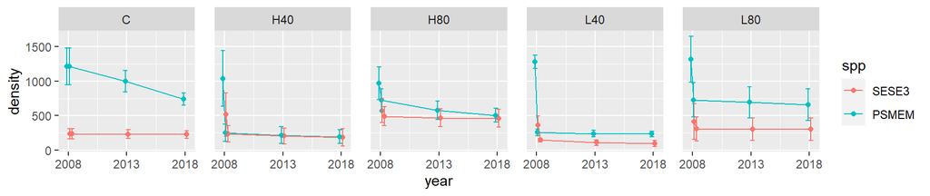

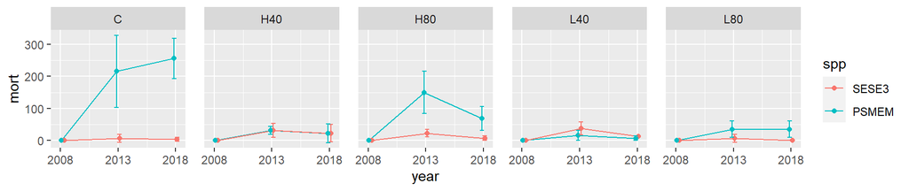

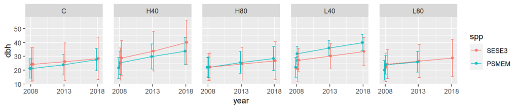

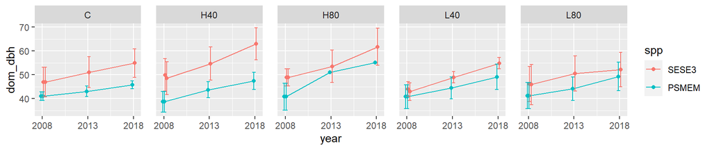

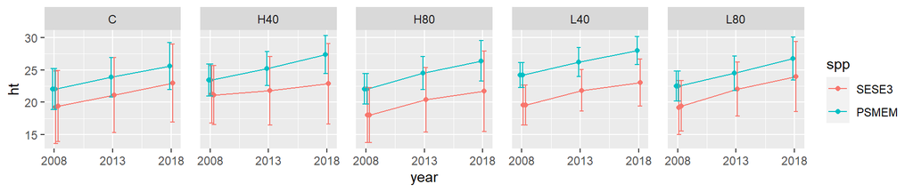

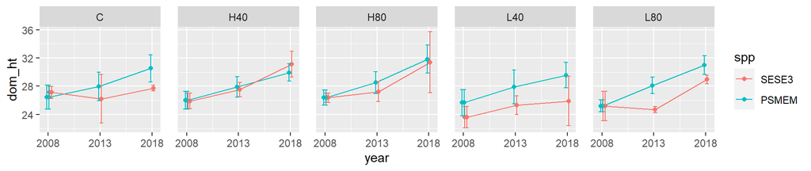

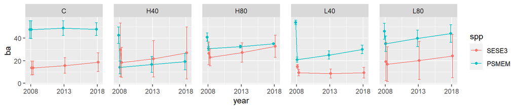

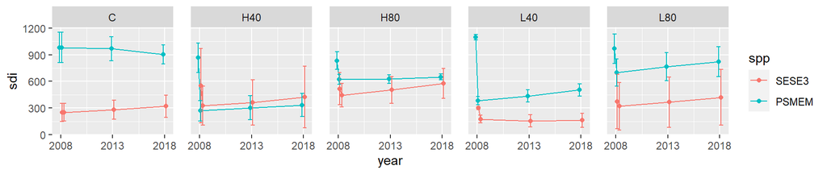